# RLS modelling results

#### Model with 1km recreational boats and avg transects

```r
total_mod_1km_avg <- gam(urch_sn_ratio_avg ~ s(sst_scale) +
                   s(norm_openness_scale) +
                   s(mean_rec_boat_counts_1km_scale)+
                   s(mean_app_fishing_hours_scale),
               data = env_mod_data_avg,
               family = gaussian(link = "identity"),
               method = 'REML',
               select = TRUE)
```

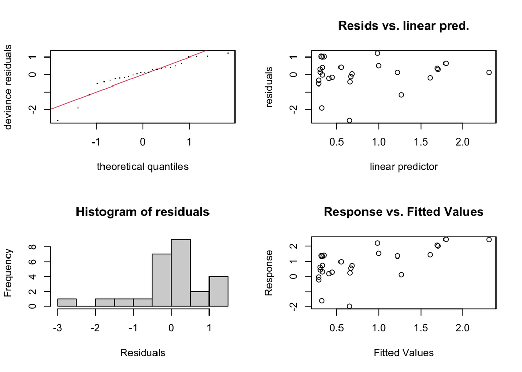

```
##
## Method: REML   Optimizer: outer newton
## full convergence after 22 iterations.
## Gradient range [-1.417636e-05,8.222464e-05]
## (score 35.69226 & scale 0.7888231).
## Hessian positive definite, eigenvalue range [1.891499e-06,12.52187].
## Model rank =  37 / 37
##
## Basis dimension (k) checking results. Low p-value (k-index<1) may
## indicate that k is too low, especially if edf is close to k'.
##
##                                         k'      edf k-index p-value
## s(sst_scale)                      9.00e+00 1.31e-04    1.07    0.60
## s(norm_openness_scale)            9.00e+00 9.09e-01    1.10    0.63
## s(mean_rec_boat_counts_1km_scale) 9.00e+00 4.90e-01    1.17    0.81
## s(mean_app_fishing_hours_scale)   9.00e+00 1.56e-05    1.02    0.46
```

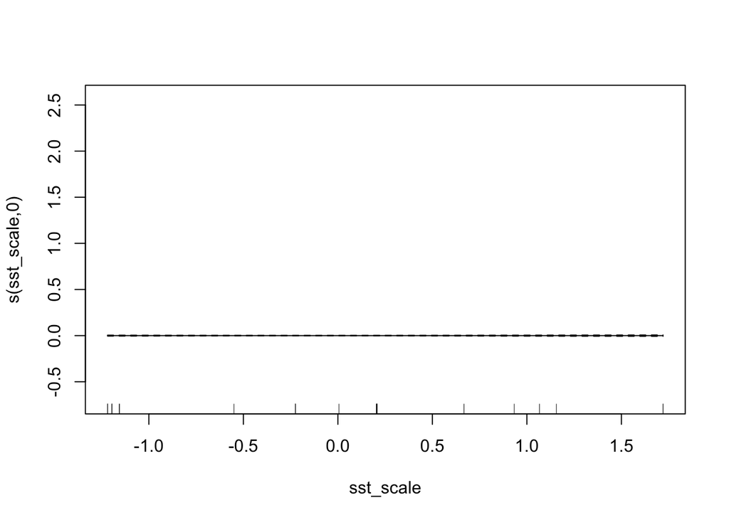

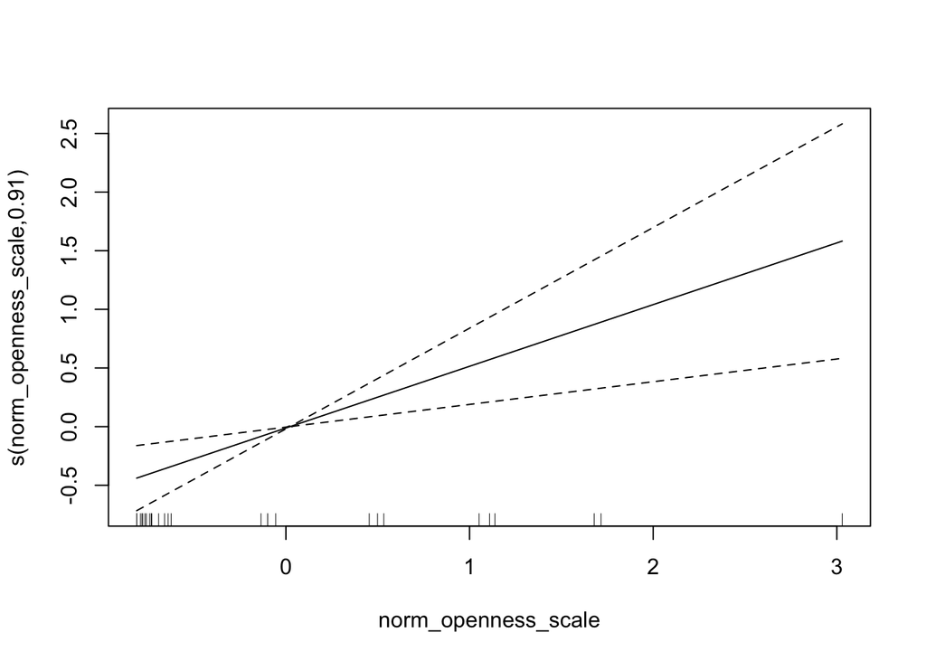

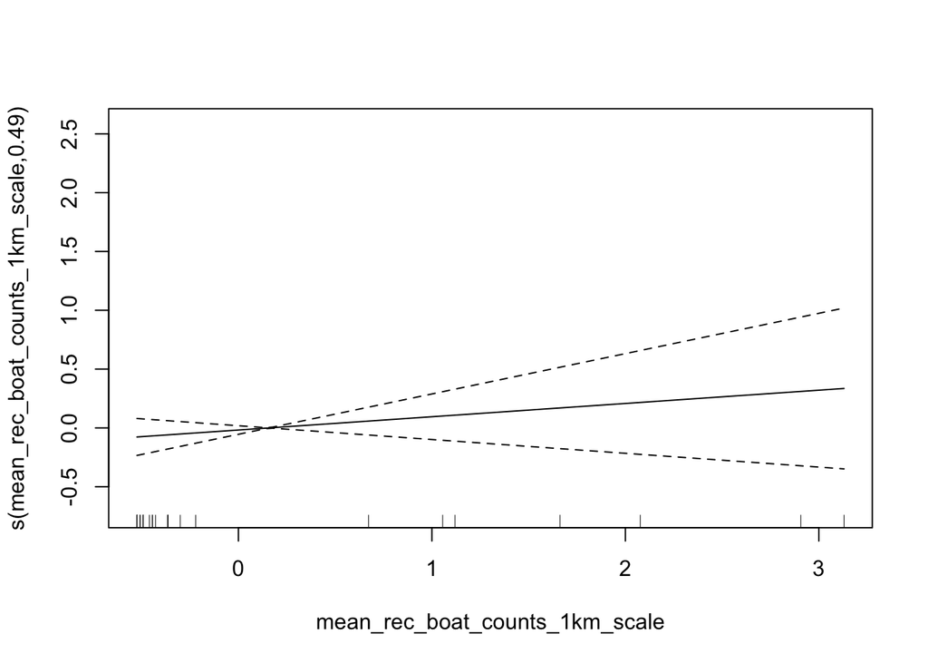

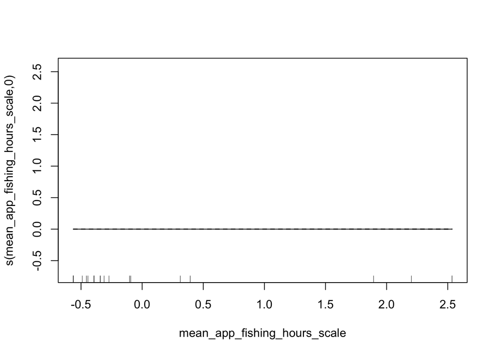

```
##
## Family: gaussian
## Link function: identity
##
## Formula:
## urch_sn_ratio_avg ~ s(sst_scale) + s(norm_openness_scale) + s(mean_rec_boat_counts_1km_scale) +
##     s(mean_app_fishing_hours_scale)
##
## Parametric coefficients:
##             Estimate Std. Error t value Pr(>|t|)
## (Intercept)   0.7994     0.1742   4.589 0.000122 ***
## ---
## Signif. codes:  0 '***' 0.001 '**' 0.01 '*' 0.05 '.' 0.1 ' ' 1
##
## Approximate significance of smooth terms:
##                                         edf Ref.df     F p-value
## s(sst_scale)                      1.308e-04      9 0.000 0.38691
## s(norm_openness_scale)            9.092e-01      9 1.113 0.00265 **
## s(mean_rec_boat_counts_1km_scale) 4.905e-01      9 0.107 0.17269
## s(mean_app_fishing_hours_scale)   1.564e-05      9 0.000 0.68594
## ---
## Signif. codes:  0 '***' 0.001 '**' 0.01 '*' 0.05 '.' 0.1 ' ' 1
##
## R-sq.(adj) =  0.335   Deviance explained = 37.2%
## -REML = 35.692  Scale est. = 0.78882   n = 26
```

##### Testing the residuals for autocorrelation

```
##
##  Moran I test under randomisation
##
## data:  residuals_total_mod_1km_avg
## weights: lw_avg
## n reduced by no-neighbour observations
##
## Moran I statistic standard deviate = 0.40154, p-value = 0.344
## alternative hypothesis: greater
## sample estimates:
## Moran I statistic       Expectation          Variance
##        0.01252289       -0.11111111        0.09480118
```

```
##
##  Moran I test under randomisation
##
## data:  residuals_total_mod_1km_avg
## weights: lw_inverse_avg
##
## Moran I statistic standard deviate = 0.92829, p-value = 0.1766
## alternative hypothesis: greater
## sample estimates:
## Moran I statistic       Expectation          Variance
##       0.027241248      -0.040000000       0.005246906
```

No evidence of autocorrelation of the residuals.

##### Testing the model for concurvity

```
## $worst
##                                           para s(sst_scale)
## para                              1.000000e+00 2.111799e-24
## s(sst_scale)                      2.106192e-24 1.000000e+00
## s(norm_openness_scale)            2.630097e-23 9.517659e-01
## s(mean_rec_boat_counts_1km_scale) 1.458459e-15 6.631493e-01
## s(mean_app_fishing_hours_scale)   1.429347e-18 9.996369e-01
##                                   s(norm_openness_scale)
## para                                        2.633319e-23
## s(sst_scale)                                9.517659e-01
## s(norm_openness_scale)                      1.000000e+00
## s(mean_rec_boat_counts_1km_scale)           9.955954e-01
## s(mean_app_fishing_hours_scale)             9.129862e-01
##                                   s(mean_rec_boat_counts_1km_scale)
## para                                                   1.458459e-15
## s(sst_scale)                                           6.631493e-01
## s(norm_openness_scale)                                 9.955954e-01
## s(mean_rec_boat_counts_1km_scale)                      1.000000e+00
## s(mean_app_fishing_hours_scale)                        9.999993e-01
##                                   s(mean_app_fishing_hours_scale)
## para                                                 1.429339e-18
## s(sst_scale)                                         9.996369e-01
## s(norm_openness_scale)                               9.129862e-01
## s(mean_rec_boat_counts_1km_scale)                    9.999993e-01
## s(mean_app_fishing_hours_scale)                      1.000000e+00
##
## $observed
##                                           para s(sst_scale)
## para                              1.000000e+00 6.118503e-30
## s(sst_scale)                      2.106192e-24 1.000000e+00
## s(norm_openness_scale)            2.630097e-23 5.525894e-01
## s(mean_rec_boat_counts_1km_scale) 1.458459e-15 4.150270e-01
## s(mean_app_fishing_hours_scale)   1.429347e-18 4.191455e-01
##                                   s(norm_openness_scale)
## para                                        1.895904e-33
## s(sst_scale)                                4.948959e-01
## s(norm_openness_scale)                      1.000000e+00
## s(mean_rec_boat_counts_1km_scale)           3.846834e-01
## s(mean_app_fishing_hours_scale)             2.048900e-01
##                                   s(mean_rec_boat_counts_1km_scale)
```

[output cut: 22 more lines]

```
## s(norm_openness_scale)                      1.000000e+00
## s(mean_rec_boat_counts_1km_scale)           3.233170e-01
## s(mean_app_fishing_hours_scale)             2.003710e-01
##                                   s(mean_rec_boat_counts_1km_scale)
## para                                                   9.544174e-18
## s(sst_scale)                                           4.144446e-01
## s(norm_openness_scale)                                 6.891063e-01
## s(mean_rec_boat_counts_1km_scale)                      1.000000e+00
## s(mean_app_fishing_hours_scale)                        6.578473e-01
##                                   s(mean_app_fishing_hours_scale)
## para                                                 1.313946e-22
## s(sst_scale)                                         3.517142e-01
## s(norm_openness_scale)                               3.150262e-01
## s(mean_rec_boat_counts_1km_scale)                    4.389427e-01
## s(mean_app_fishing_hours_scale)                      1.000000e+00
```

Some of the variables appear to have high concurvity scores in the worst case, but confidence intervals seem stable for the model plots. May need to get rid of the mean apparent fishing hours however. Since the concurvity was very high.

#### Model with 1.5km recreational boats and avg transects

```r
total_mod_1.5km_avg <- gam(urch_sn_ratio_avg ~ s(sst_scale) +
                   s(norm_openness_scale) +
                   s(mean_rec_boat_counts_1.5km_scale)+
                   s(mean_app_fishing_hours_scale),
               data = env_mod_data_avg,
               family = gaussian(link = "identity"),
               method = 'REML',
               select = TRUE)
```

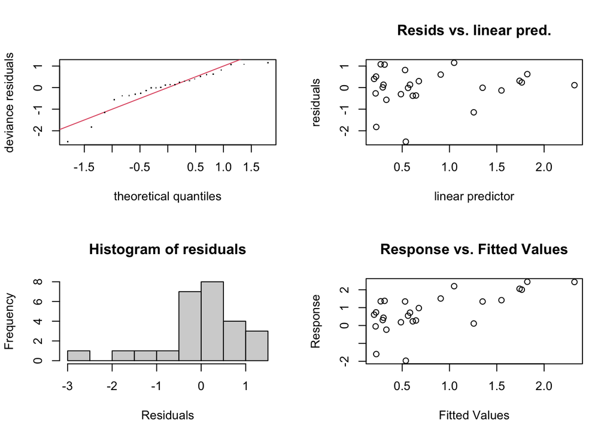

```
##
## Method: REML   Optimizer: outer newton
## full convergence after 15 iterations.
## Gradient range [-1.343292e-05,1.007968e-05]
## (score 35.52545 & scale 0.7558856).
## Hessian positive definite, eigenvalue range [2.329443e-07,12.52759].
## Model rank =  37 / 37
##
## Basis dimension (k) checking results. Low p-value (k-index<1) may
## indicate that k is too low, especially if edf is close to k'.
##
##                                           k'      edf k-index p-value
## s(sst_scale)                        9.00e+00 3.64e-01    1.07    0.58
## s(norm_openness_scale)              9.00e+00 9.09e-01    1.10    0.63
## s(mean_rec_boat_counts_1.5km_scale) 9.00e+00 6.22e-01    1.05    0.60
## s(mean_app_fishing_hours_scale)     9.00e+00 4.40e-06    1.05    0.51
```

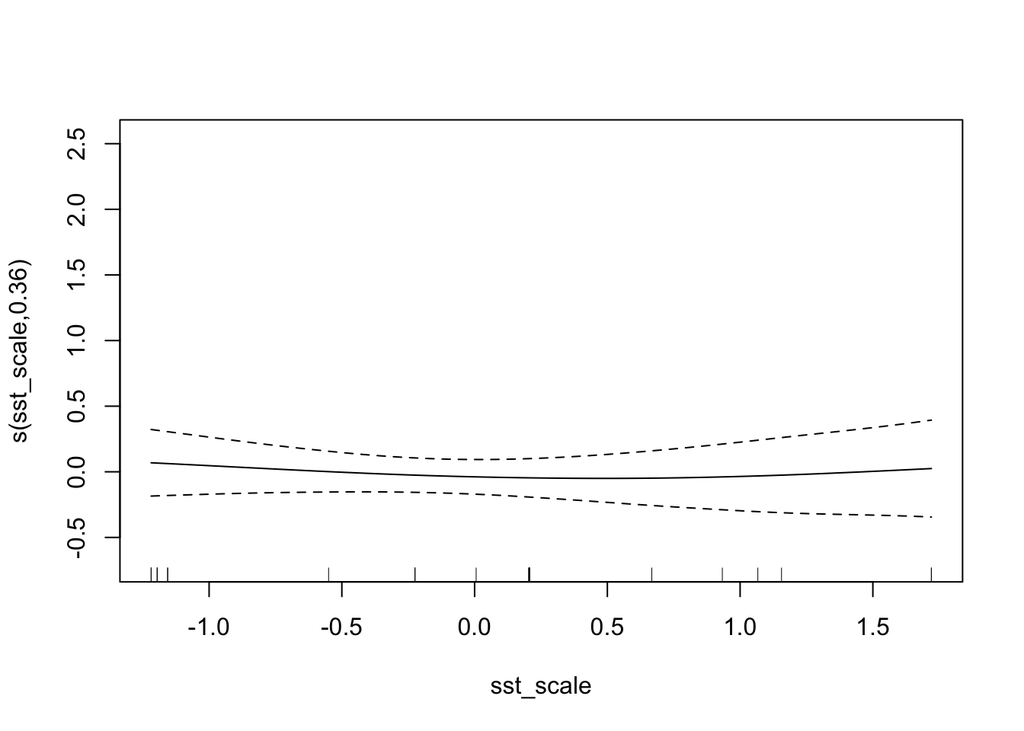

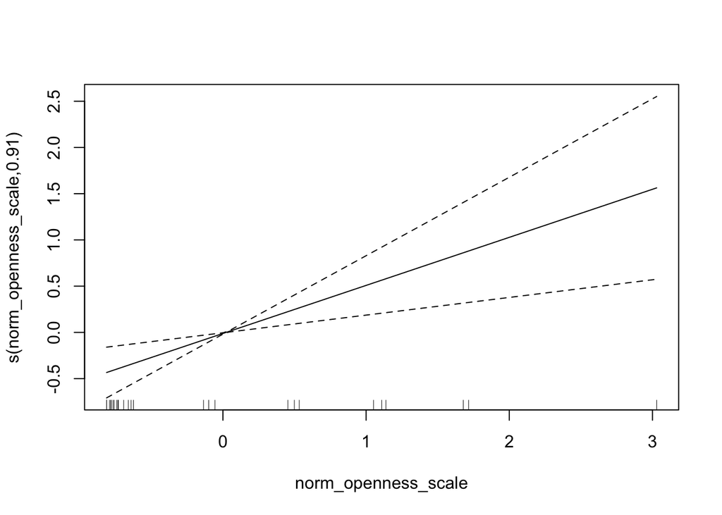

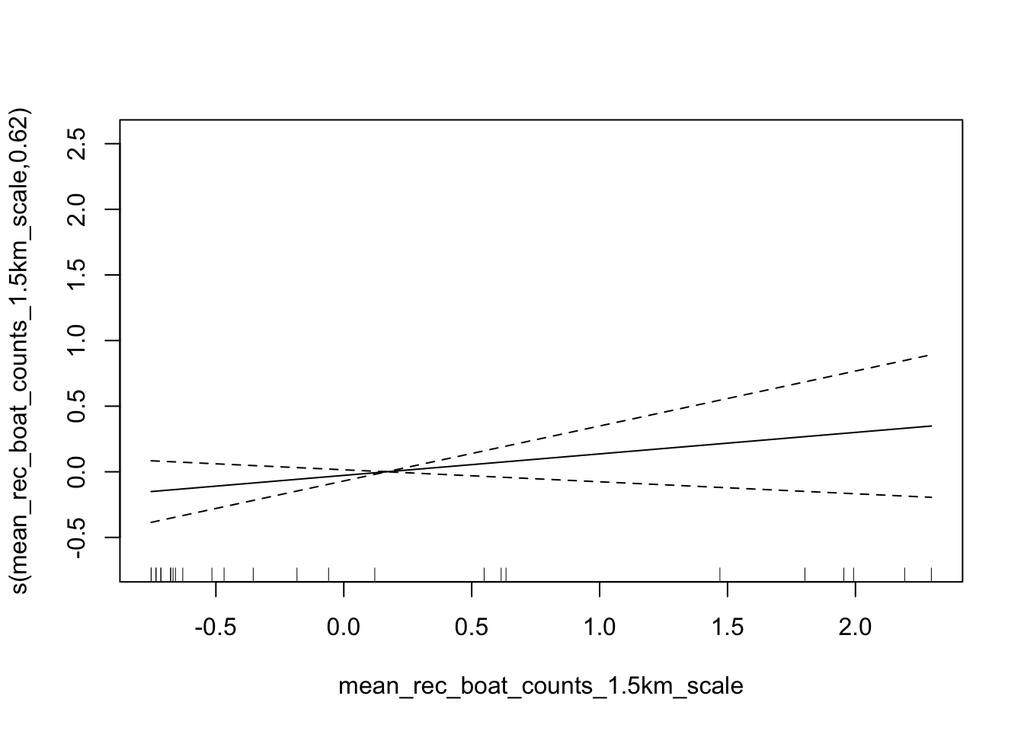

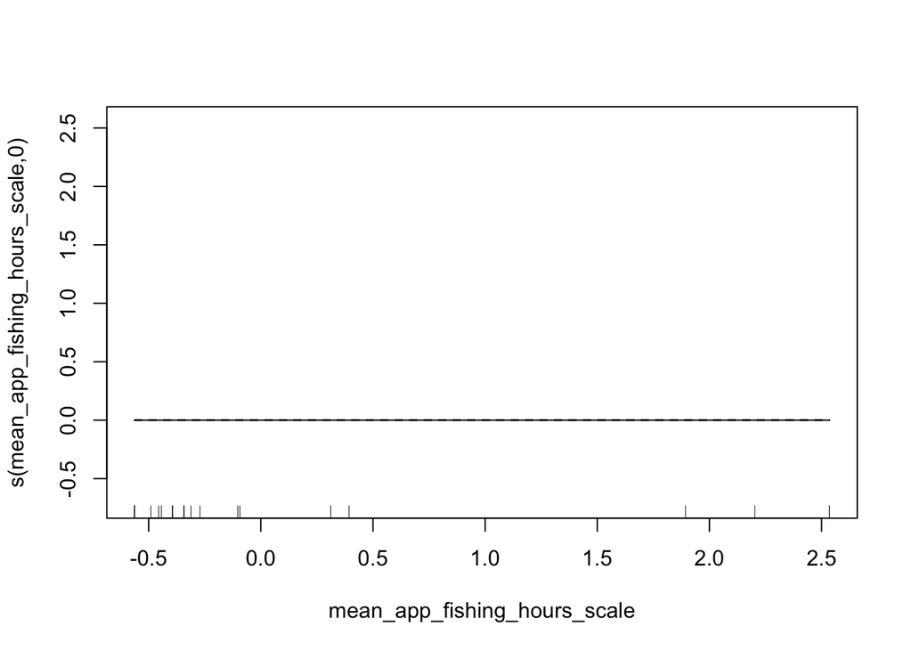

```
##
## Family: gaussian
## Link function: identity
##
## Formula:
## urch_sn_ratio_avg ~ s(sst_scale) + s(norm_openness_scale) + s(mean_rec_boat_counts_1.5km_scale) +
##     s(mean_app_fishing_hours_scale)
##
## Parametric coefficients:
##             Estimate Std. Error t value Pr(>|t|)
## (Intercept)   0.7994     0.1705   4.688    1e-04 ***
## ---
## Signif. codes:  0 '***' 0.001 '**' 0.01 '*' 0.05 '.' 0.1 ' ' 1
##
## Approximate significance of smooth terms:
##                                           edf Ref.df     F p-value
## s(sst_scale)                        3.635e-01      9 0.048 0.30789
## s(norm_openness_scale)              9.092e-01      9 1.112 0.00252 **
## s(mean_rec_boat_counts_1.5km_scale) 6.224e-01      9 0.187 0.11492
## s(mean_app_fishing_hours_scale)     4.397e-06      9 0.000 0.58115
## ---
## Signif. codes:  0 '***' 0.001 '**' 0.01 '*' 0.05 '.' 0.1 ' ' 1
##
## R-sq.(adj) =  0.363   Deviance explained = 41.1%
## -REML = 35.525  Scale est. = 0.75589   n = 26
```

##### Testing the residuals for autocorrelation

```
##
##  Moran I test under randomisation
##
## data:  residuals_total_mod_1.5km_avg
## weights: lw_avg
## n reduced by no-neighbour observations
##
## Moran I statistic standard deviate = 0.43676, p-value = 0.3311
## alternative hypothesis: greater
## sample estimates:
## Moran I statistic       Expectation          Variance
##        0.02806582       -0.11111111        0.10154365
```

```
##
##  Moran I test under randomisation
##
## data:  residuals_total_mod_1.5km_avg
## weights: lw_inverse_avg
##
## Moran I statistic standard deviate = 0.8629, p-value = 0.1941
## alternative hypothesis: greater
## sample estimates:
## Moran I statistic       Expectation          Variance
##       0.022845998      -0.040000000       0.005304416
```

No evidence of autocorrelation of the residuals.

##### Testing the model for concurvity

```
## $worst
##                                             para s(sst_scale)
## para                                1.000000e+00 2.111799e-24
## s(sst_scale)                        2.106192e-24 1.000000e+00
## s(norm_openness_scale)              2.630097e-23 9.517659e-01
## s(mean_rec_boat_counts_1.5km_scale) 1.111302e-17 9.316319e-01
## s(mean_app_fishing_hours_scale)     1.429360e-18 9.996369e-01
##                                     s(norm_openness_scale)
## para                                          2.633319e-23
## s(sst_scale)                                  9.517659e-01
## s(norm_openness_scale)                        1.000000e+00
## s(mean_rec_boat_counts_1.5km_scale)           8.573071e-01
## s(mean_app_fishing_hours_scale)               9.129862e-01
##                                     s(mean_rec_boat_counts_1.5km_scale)
## para                                                       1.111301e-17
## s(sst_scale)                                               9.316319e-01
## s(norm_openness_scale)                                     8.573071e-01
## s(mean_rec_boat_counts_1.5km_scale)                        1.000000e+00
## s(mean_app_fishing_hours_scale)                            9.999677e-01
##                                     s(mean_app_fishing_hours_scale)
## para                                                   1.429339e-18
## s(sst_scale)                                           9.996369e-01
## s(norm_openness_scale)                                 9.129862e-01
## s(mean_rec_boat_counts_1.5km_scale)                    9.999677e-01
## s(mean_app_fishing_hours_scale)                        1.000000e+00
##
## $observed
##                                             para s(sst_scale)
## para                                1.000000e+00 2.734760e-30
## s(sst_scale)                        2.106192e-24 1.000000e+00
## s(norm_openness_scale)              2.630097e-23 5.195980e-01
## s(mean_rec_boat_counts_1.5km_scale) 1.111302e-17 2.032002e-01
## s(mean_app_fishing_hours_scale)     1.429360e-18 4.912406e-01
##                                     s(norm_openness_scale)
## para                                          1.893740e-33
## s(sst_scale)                                  4.948962e-01
## s(norm_openness_scale)                        1.000000e+00
## s(mean_rec_boat_counts_1.5km_scale)           4.503770e-01
## s(mean_app_fishing_hours_scale)               2.048903e-01
##                                     s(mean_rec_boat_counts_1.5km_scale)
```

[output cut: 22 more lines]

```
## s(norm_openness_scale)                        1.000000e+00
## s(mean_rec_boat_counts_1.5km_scale)           4.581371e-01
## s(mean_app_fishing_hours_scale)               2.003710e-01
##                                     s(mean_rec_boat_counts_1.5km_scale)
## para                                                       3.711270e-21
## s(sst_scale)                                               4.448882e-01
## s(norm_openness_scale)                                     4.252366e-01
## s(mean_rec_boat_counts_1.5km_scale)                        1.000000e+00
## s(mean_app_fishing_hours_scale)                            4.856133e-01
##                                     s(mean_app_fishing_hours_scale)
## para                                                   1.313946e-22
## s(sst_scale)                                           3.517142e-01
## s(norm_openness_scale)                                 3.150262e-01
## s(mean_rec_boat_counts_1.5km_scale)                    3.763568e-01
## s(mean_app_fishing_hours_scale)                        1.000000e+00
```

Some of the variables appear to have high concurvity scores in the worst case, but confidence intervals seem stable for the model plots. May need to get rid of the mean apparent fishing hours however. Since the concurvity was very high.

#### Model with 2km recreational boats and avg transects

```r
total_mod_2km_avg <- gam(urch_sn_ratio_avg ~ s(sst_scale) +
                   s(norm_openness_scale) +
                   s(mean_rec_boat_counts_2km_scale)+
                   s(mean_app_fishing_hours_scale),
               data = env_mod_data_avg,
               family = gaussian(link = "identity"),
               method = 'REML',
               select = TRUE)
```

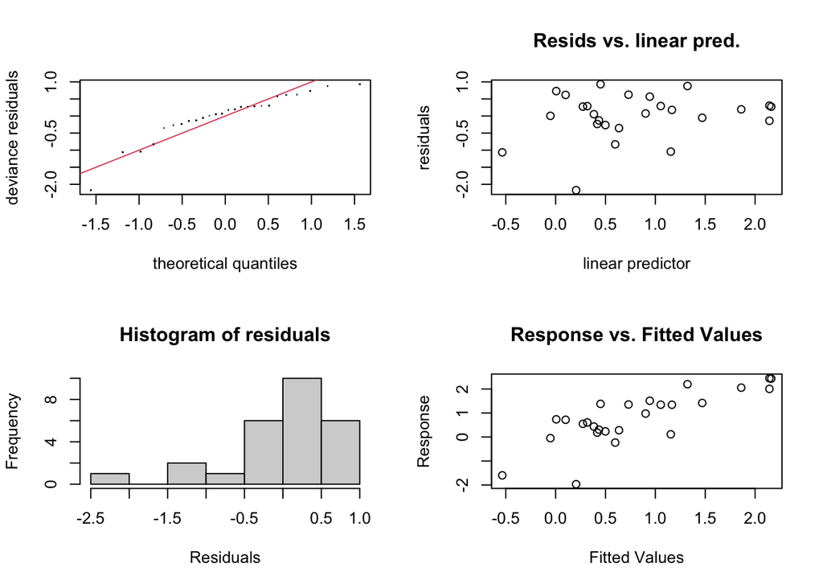

```
##
## Method: REML   Optimizer: outer newton
## full convergence after 19 iterations.
## Gradient range [-7.627228e-05,0.0001608317]
## (score 34.52793 & scale 0.568447).
## Hessian positive definite, eigenvalue range [2.763213e-06,12.61088].
## Model rank =  37 / 37
##
## Basis dimension (k) checking results. Low p-value (k-index<1) may
## indicate that k is too low, especially if edf is close to k'.
##
##                                      k'   edf k-index p-value
## s(sst_scale)                      9.000 1.498    1.06    0.53
## s(norm_openness_scale)            9.000 0.883    1.12    0.63
## s(mean_rec_boat_counts_2km_scale) 9.000 1.558    1.14    0.74
## s(mean_app_fishing_hours_scale)   9.000 0.538    1.16    0.72
```

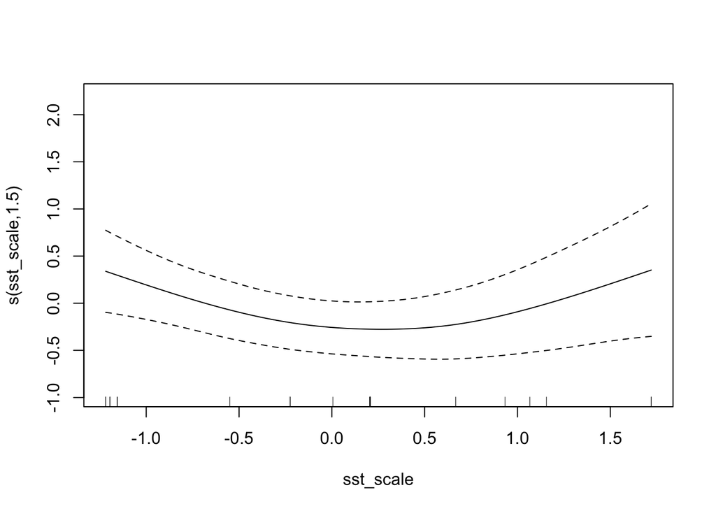

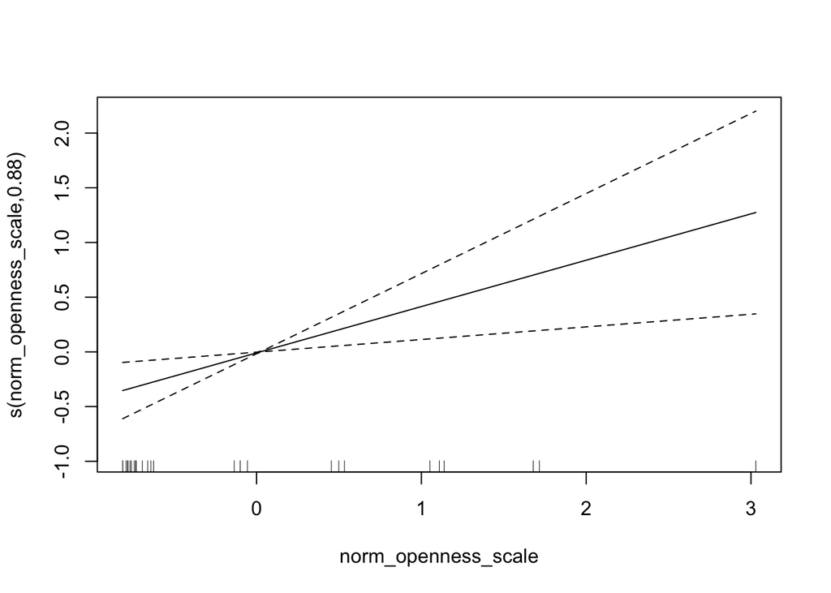

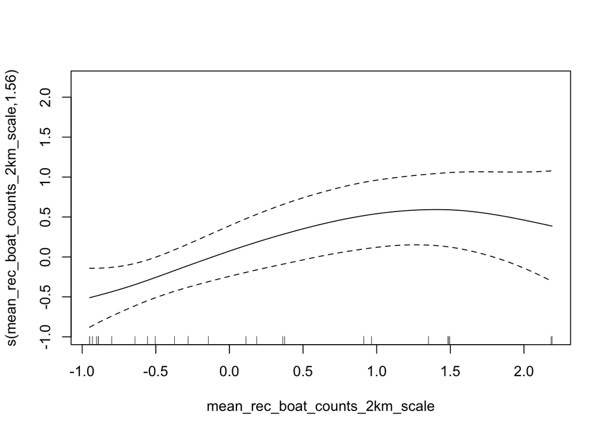

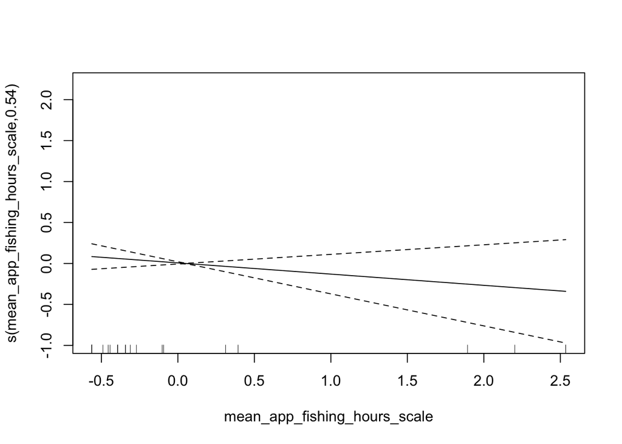

```
##
## Family: gaussian
## Link function: identity
##
## Formula:
## urch_sn_ratio_avg ~ s(sst_scale) + s(norm_openness_scale) + s(mean_rec_boat_counts_2km_scale) +
##     s(mean_app_fishing_hours_scale)
##
## Parametric coefficients:
##             Estimate Std. Error t value Pr(>|t|)
## (Intercept)   0.7994     0.1479   5.406  2.5e-05 ***
## ---
## Signif. codes:  0 '***' 0.001 '**' 0.01 '*' 0.05 '.' 0.1 ' ' 1
##
## Approximate significance of smooth terms:
##                                      edf Ref.df     F p-value
## s(sst_scale)                      1.4983      9 0.461 0.07350 .
## s(norm_openness_scale)            0.8832      9 0.840 0.00606 **
## s(mean_rec_boat_counts_2km_scale) 1.5578      9 0.927 0.00966 **
## s(mean_app_fishing_hours_scale)   0.5376      9 0.129 0.14479
## ---
## Signif. codes:  0 '***' 0.001 '**' 0.01 '*' 0.05 '.' 0.1 ' ' 1
##
## R-sq.(adj) =  0.521   Deviance explained = 60.7%
## -REML = 34.528  Scale est. = 0.56845   n = 26
```

##### Testing the residuals for autocorrelation

```
##
##  Moran I test under randomisation
##
## data:  residuals_total_mod_2km_avg
## weights: lw_avg
## n reduced by no-neighbour observations
##
## Moran I statistic standard deviate = 0.4504, p-value = 0.3262
## alternative hypothesis: greater
## sample estimates:
## Moran I statistic       Expectation          Variance
##        0.02545537       -0.11111111        0.09193561
```

```
##
##  Moran I test under randomisation
##
## data:  residuals_total_mod_2km_avg
## weights: lw_inverse_avg
##
## Moran I statistic standard deviate = 0.21484, p-value = 0.4149
## alternative hypothesis: greater
## sample estimates:
## Moran I statistic       Expectation          Variance
##      -0.024474347      -0.040000000       0.005222464
```

No evidence of autocorrelation of the residuals.

##### Testing the model for concurvity

```
## $worst
##                                           para s(sst_scale)
## para                              1.000000e+00 2.111799e-24
## s(sst_scale)                      2.106192e-24 1.000000e+00
## s(norm_openness_scale)            2.630097e-23 9.517659e-01
## s(mean_rec_boat_counts_2km_scale) 9.077705e-17 8.878102e-01
## s(mean_app_fishing_hours_scale)   1.429334e-18 9.996369e-01
##                                   s(norm_openness_scale)
## para                                        2.633319e-23
## s(sst_scale)                                9.517659e-01
## s(norm_openness_scale)                      1.000000e+00
## s(mean_rec_boat_counts_2km_scale)           8.511249e-01
## s(mean_app_fishing_hours_scale)             9.129862e-01
##                                   s(mean_rec_boat_counts_2km_scale)
## para                                                   9.077710e-17
## s(sst_scale)                                           8.878102e-01
## s(norm_openness_scale)                                 8.511249e-01
## s(mean_rec_boat_counts_2km_scale)                      1.000000e+00
## s(mean_app_fishing_hours_scale)                        9.985733e-01
##                                   s(mean_app_fishing_hours_scale)
## para                                                 1.429339e-18
## s(sst_scale)                                         9.996369e-01
## s(norm_openness_scale)                               9.129862e-01
## s(mean_rec_boat_counts_2km_scale)                    9.985733e-01
## s(mean_app_fishing_hours_scale)                      1.000000e+00
##
## $observed
##                                           para s(sst_scale)
## para                              1.000000e+00 1.160945e-30
## s(sst_scale)                      2.106192e-24 1.000000e+00
## s(norm_openness_scale)            2.630097e-23 4.341382e-01
## s(mean_rec_boat_counts_2km_scale) 9.077705e-17 4.260950e-01
## s(mean_app_fishing_hours_scale)   1.429334e-18 6.047597e-01
##                                   s(norm_openness_scale)
## para                                        1.895769e-33
## s(sst_scale)                                4.948959e-01
## s(norm_openness_scale)                      1.000000e+00
## s(mean_rec_boat_counts_2km_scale)           2.050346e-01
## s(mean_app_fishing_hours_scale)             2.048900e-01
##                                   s(mean_rec_boat_counts_2km_scale)
```

[output cut: 22 more lines]

```
## s(norm_openness_scale)                      1.000000e+00
## s(mean_rec_boat_counts_2km_scale)           2.359172e-01
## s(mean_app_fishing_hours_scale)             2.003710e-01
##                                   s(mean_rec_boat_counts_2km_scale)
## para                                                   7.190114e-20
## s(sst_scale)                                           5.410720e-01
## s(norm_openness_scale)                                 3.130322e-01
## s(mean_rec_boat_counts_2km_scale)                      1.000000e+00
## s(mean_app_fishing_hours_scale)                        5.248918e-01
##                                   s(mean_app_fishing_hours_scale)
## para                                                 1.313946e-22
## s(sst_scale)                                         3.517142e-01
## s(norm_openness_scale)                               3.150262e-01
## s(mean_rec_boat_counts_2km_scale)                    4.621033e-01
## s(mean_app_fishing_hours_scale)                      1.000000e+00
```

Some of the variables appear to have high concurvity scores in the worst case, but confidence intervals seem stable for the model plots. May need to get rid of the mean apparent fishing hours however. Since the concurvity was very high.

### Building GAMs to test the effects on the Urchin to snail ratio (without mean apparent fishing hours)

Redoing the GAMs without the mean apparent fishing hours because the concurvity is very high.

#### Model with 1 km recreational boats (no mean app hours)

```r
total_mod_1km_no_app_hours <- gam(urch_sn_ratio ~ s(sst_scale) +
                   s(norm_openness_scale) +
                   s(mean_rec_boat_counts_1km_scale),
               data = env_mod_data,
               family = gaussian(link = "identity"),
               method = 'REML',
               select = TRUE)
```

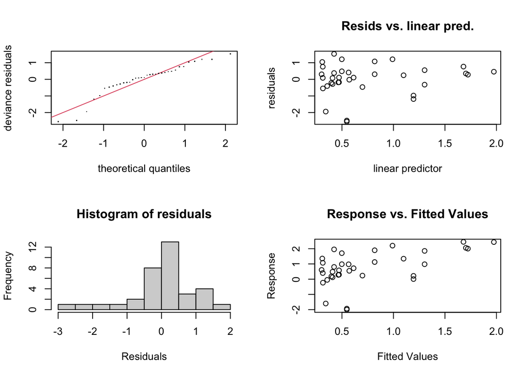

```
##
## Method: REML   Optimizer: outer newton
## full convergence after 14 iterations.
## Gradient range [-1.056124e-05,4.525027e-05]
## (score 50.68582 & scale 0.9373872).
## Hessian positive definite, eigenvalue range [1.128777e-06,17.02059].
## Model rank =  28 / 28
##
## Basis dimension (k) checking results. Low p-value (k-index<1) may
## indicate that k is too low, especially if edf is close to k'.
##
##                                      k'   edf k-index p-value
## s(sst_scale)                      9.000 0.589    0.71    0.02 *
## s(norm_openness_scale)            9.000 0.860    0.68    0.02 *
## s(mean_rec_boat_counts_1km_scale) 9.000 0.543    0.78    0.10 .
## ---
## Signif. codes:  0 '***' 0.001 '**' 0.01 '*' 0.05 '.' 0.1 ' ' 1
```

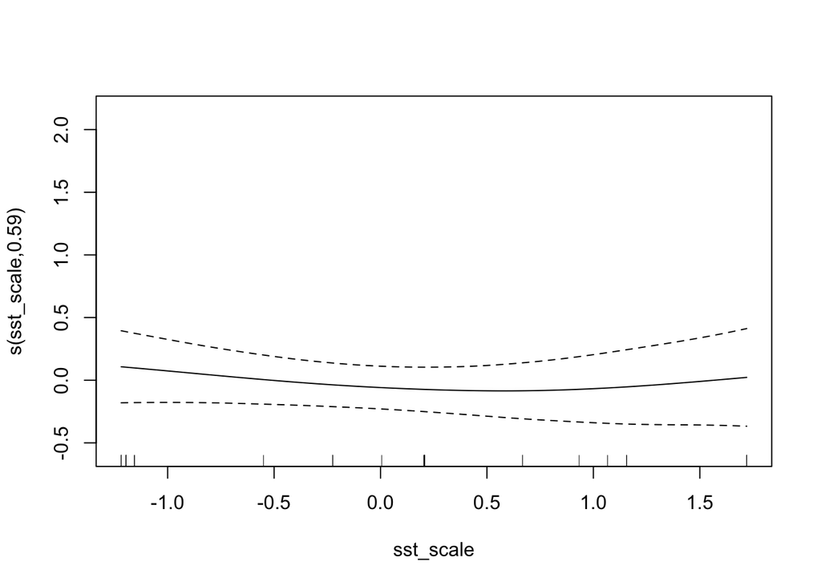

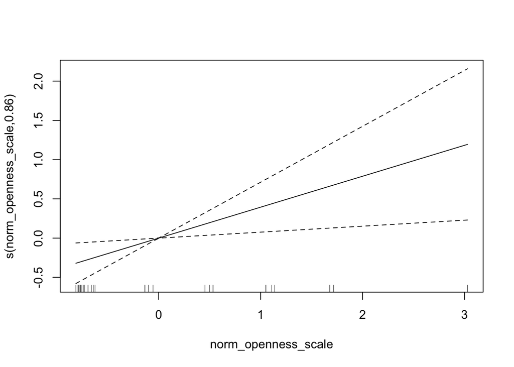

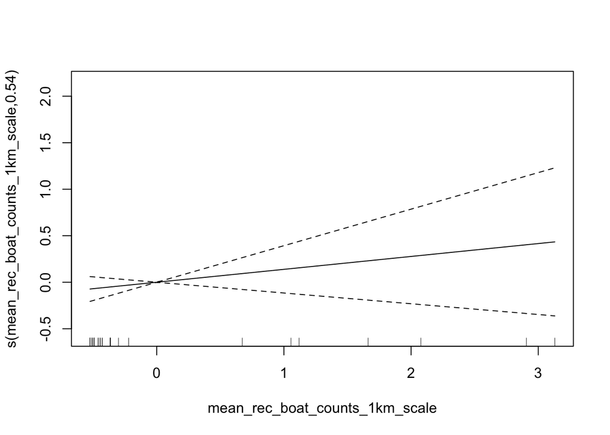

```
##
## Family: gaussian
## Link function: identity
##
## Formula:
## urch_sn_ratio ~ s(sst_scale) + s(norm_openness_scale) + s(mean_rec_boat_counts_1km_scale)
##
## Parametric coefficients:
##             Estimate Std. Error t value Pr(>|t|)
## (Intercept)   0.7446     0.1637    4.55 7.32e-05 ***
## ---
## Signif. codes:  0 '***' 0.001 '**' 0.01 '*' 0.05 '.' 0.1 ' ' 1
##
## Approximate significance of smooth terms:
##                                      edf Ref.df     F p-value
## s(sst_scale)                      0.5891      9 0.088  0.2639
## s(norm_openness_scale)            0.8601      9 0.683  0.0105 *
## s(mean_rec_boat_counts_1km_scale) 0.5432      9 0.132  0.1450
## ---
## Signif. codes:  0 '***' 0.001 '**' 0.01 '*' 0.05 '.' 0.1 ' ' 1
##
## R-sq.(adj) =  0.233   Deviance explained = 27.8%
## -REML = 50.686  Scale est. = 0.93739   n = 35
```

##### Testing the residuals for autocorrelation

```
##
##  Moran I test under randomisation
##
## data:  residuals_total_mod_1km_no_app_hours
## weights: lw
## n reduced by no-neighbour observations
##
## Moran I statistic standard deviate = 2.132, p-value = 0.0165
## alternative hypothesis: greater
## sample estimates:
## Moran I statistic       Expectation          Variance
##        0.58862106       -0.05882353        0.09222277
```

It appears that the residuals are autocorrelated. Will need to address this.

##### Testing the model for concurvity

```
## $worst
##                                           para s(sst_scale)
## para                              1.000000e+00 4.176841e-24
## s(sst_scale)                      4.182745e-24 1.000000e+00
## s(norm_openness_scale)            1.365135e-17 9.527043e-01
## s(mean_rec_boat_counts_1km_scale) 1.128657e-15 6.412812e-01
##                                   s(norm_openness_scale)
## para                                        1.365142e-17
## s(sst_scale)                                9.527043e-01
## s(norm_openness_scale)                      1.000000e+00
## s(mean_rec_boat_counts_1km_scale)           9.941979e-01
##                                   s(mean_rec_boat_counts_1km_scale)
## para                                                   1.128657e-15
## s(sst_scale)                                           6.412812e-01
## s(norm_openness_scale)                                 9.941979e-01
## s(mean_rec_boat_counts_1km_scale)                      1.000000e+00
##
## $observed
##                                           para s(sst_scale)
## para                              1.000000e+00 8.332152e-31
## s(sst_scale)                      4.182745e-24 1.000000e+00
## s(norm_openness_scale)            1.365135e-17 4.884693e-01
## s(mean_rec_boat_counts_1km_scale) 1.128657e-15 3.093512e-01
##                                   s(norm_openness_scale)
## para                                        1.548830e-34
## s(sst_scale)                                4.675617e-01
## s(norm_openness_scale)                      1.000000e+00
## s(mean_rec_boat_counts_1km_scale)           3.406236e-01
##                                   s(mean_rec_boat_counts_1km_scale)
## para                                                   8.399144e-33
## s(sst_scale)                                           2.893085e-01
## s(norm_openness_scale)                                 5.691597e-01
## s(mean_rec_boat_counts_1km_scale)                      1.000000e+00
##
## $estimate
##                                           para s(sst_scale)
## para                              1.000000e+00 9.168891e-28
## s(sst_scale)                      4.182745e-24 1.000000e+00
## s(norm_openness_scale)            1.365135e-17 4.621752e-01
## s(mean_rec_boat_counts_1km_scale) 1.128657e-15 1.906244e-01
##                                   s(norm_openness_scale)
## para                                        2.363901e-21
## s(sst_scale)                                4.716431e-01
## s(norm_openness_scale)                      1.000000e+00
## s(mean_rec_boat_counts_1km_scale)           2.832631e-01
##                                   s(mean_rec_boat_counts_1km_scale)
## para                                                   5.525403e-18
## s(sst_scale)                                           2.865567e-01
## s(norm_openness_scale)                                 6.765577e-01
## s(mean_rec_boat_counts_1km_scale)                      1.000000e+00
```

Some of the variables appear to still have high concurvity scores in the worst case, but confidence intervals seem stable for the model plots.

#### Model with 1.5 km recreational boats (no mean app hours)

```r
total_mod_1.5km_no_app_hours <- gam(urch_sn_ratio ~ s(sst_scale) +
                   s(norm_openness_scale) +
                   s(mean_rec_boat_counts_1.5km_scale),
               data = env_mod_data,
               family = gaussian(link = "identity"),
               method = 'REML',
               select = TRUE)
```

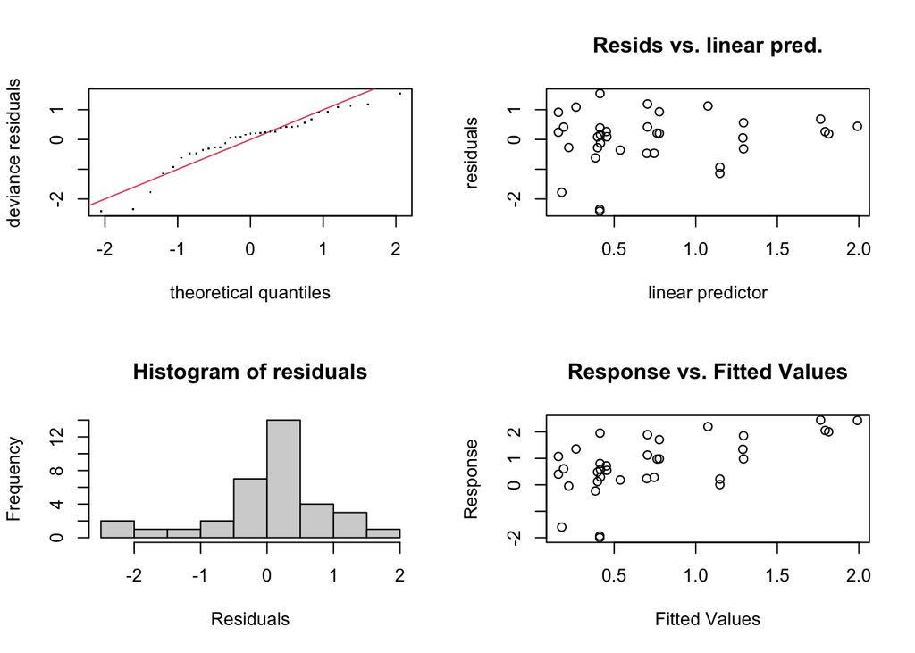

```
##
## Method: REML   Optimizer: outer newton
## full convergence after 28 iterations.
## Gradient range [-1.473116e-06,3.043547e-06]
## (score 50.30443 & scale 0.881638).
## Hessian positive definite, eigenvalue range [3.539494e-07,17.03092].
## Model rank =  28 / 28
##
## Basis dimension (k) checking results. Low p-value (k-index<1) may
## indicate that k is too low, especially if edf is close to k'.
##
##                                        k'   edf k-index p-value
## s(sst_scale)                        9.000 0.949    0.70    0.02 *
## s(norm_openness_scale)              9.000 0.870    0.69    0.03 *
## s(mean_rec_boat_counts_1.5km_scale) 9.000 0.823    0.82    0.13
## ---
## Signif. codes:  0 '***' 0.001 '**' 0.01 '*' 0.05 '.' 0.1 ' ' 1
```

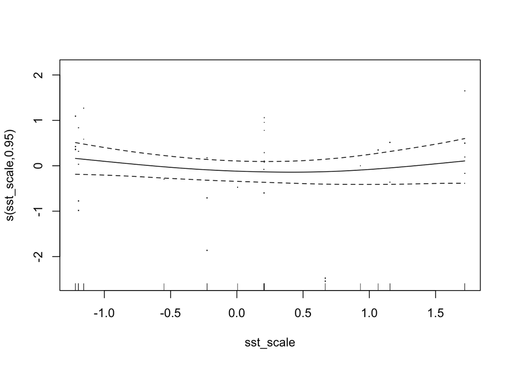

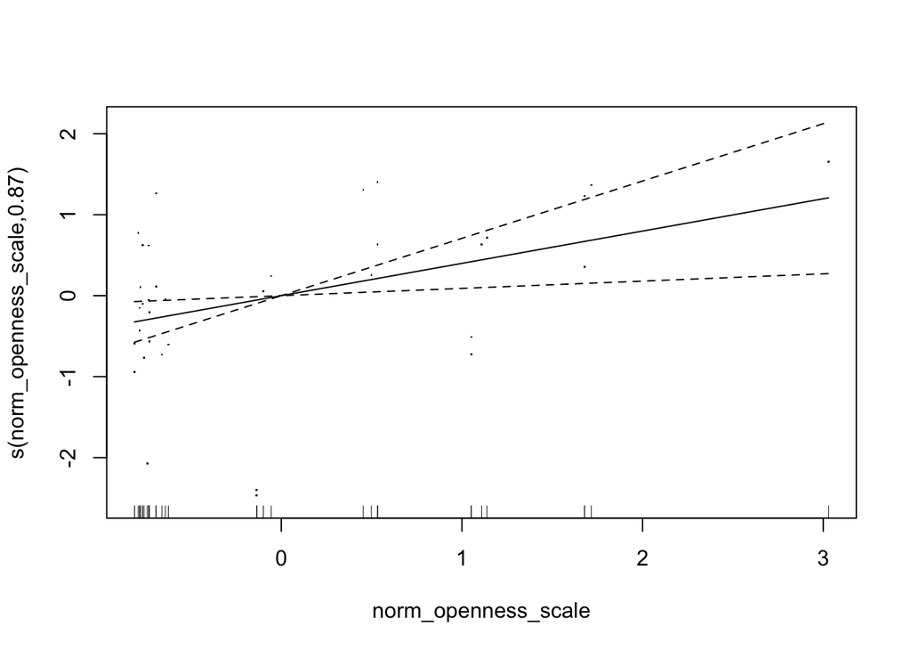

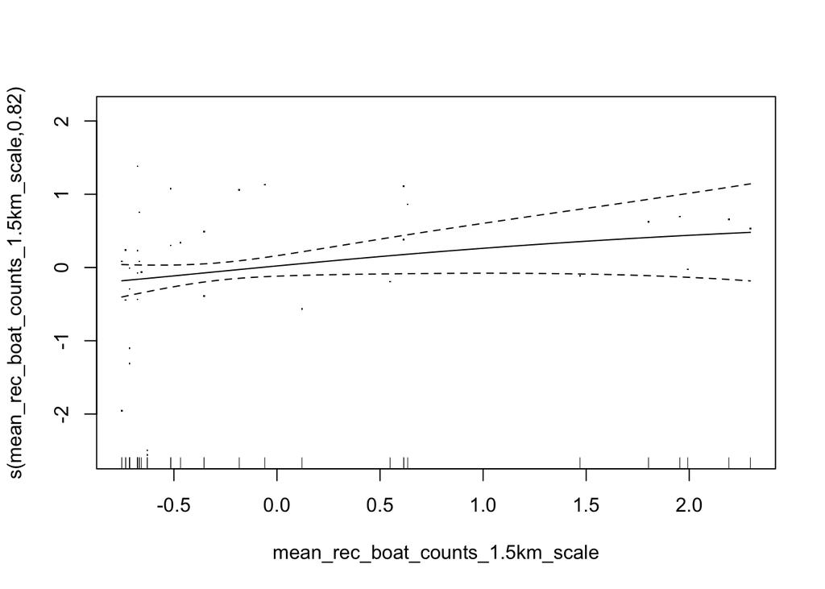

```
##
## Family: gaussian
## Link function: identity
##
## Formula:
## urch_sn_ratio ~ s(sst_scale) + s(norm_openness_scale) + s(mean_rec_boat_counts_1.5km_scale)
##
## Parametric coefficients:
##             Estimate Std. Error t value Pr(>|t|)
## (Intercept)   0.7446     0.1587   4.691 5.07e-05 ***
## ---
## Signif. codes:  0 '***' 0.001 '**' 0.01 '*' 0.05 '.' 0.1 ' ' 1
##
## Approximate significance of smooth terms:
##                                        edf Ref.df     F p-value
## s(sst_scale)                        0.9488      9 0.172 0.20262
## s(norm_openness_scale)              0.8695      9 0.741 0.00856 **
## s(mean_rec_boat_counts_1.5km_scale) 0.8228      9 0.301 0.06578 .
## ---
## Signif. codes:  0 '***' 0.001 '**' 0.01 '*' 0.05 '.' 0.1 ' ' 1
##
## R-sq.(adj) =  0.278   Deviance explained = 33.5%
## -REML = 50.304  Scale est. = 0.88164   n = 35
```

##### Testing the residuals for autocorrelation

```
##
##  Moran I test under randomisation
##
## data:  residuals_total_mod_1.5km_no_app_hours
## weights: lw
## n reduced by no-neighbour observations
##
## Moran I statistic standard deviate = 2.0855, p-value = 0.01851
## alternative hypothesis: greater
## sample estimates:
## Moran I statistic       Expectation          Variance
##        0.58005525       -0.05882353        0.09384564
```

It appears that the residuals are autocorrelated. Will need to address this.

##### Testing the model for concurvity

```
## $worst
##                                             para s(sst_scale)
## para                                1.000000e+00 4.176841e-24
## s(sst_scale)                        4.182745e-24 1.000000e+00
## s(norm_openness_scale)              1.365135e-17 9.527043e-01
## s(mean_rec_boat_counts_1.5km_scale) 5.774936e-16 9.357699e-01
##                                     s(norm_openness_scale)
## para                                          1.365142e-17
## s(sst_scale)                                  9.527043e-01
## s(norm_openness_scale)                        1.000000e+00
## s(mean_rec_boat_counts_1.5km_scale)           8.702294e-01
##                                     s(mean_rec_boat_counts_1.5km_scale)
## para                                                       5.774935e-16
## s(sst_scale)                                               9.357699e-01
## s(norm_openness_scale)                                     8.702294e-01
## s(mean_rec_boat_counts_1.5km_scale)                        1.000000e+00
##
## $observed
##                                             para s(sst_scale)
## para                                1.000000e+00 5.751901e-32
## s(sst_scale)                        4.182745e-24 1.000000e+00
## s(norm_openness_scale)              1.365135e-17 4.300148e-01
## s(mean_rec_boat_counts_1.5km_scale) 5.774936e-16 2.217225e-01
##                                     s(norm_openness_scale)
## para                                          9.867145e-34
## s(sst_scale)                                  4.675591e-01
## s(norm_openness_scale)                        1.000000e+00
## s(mean_rec_boat_counts_1.5km_scale)           4.563988e-01
##                                     s(mean_rec_boat_counts_1.5km_scale)
## para                                                       5.527858e-23
## s(sst_scale)                                               3.856366e-01
## s(norm_openness_scale)                                     4.042342e-01
## s(mean_rec_boat_counts_1.5km_scale)                        1.000000e+00
##
## $estimate
##                                             para s(sst_scale)
## para                                1.000000e+00 9.168891e-28
## s(sst_scale)                        4.182745e-24 1.000000e+00
## s(norm_openness_scale)              1.365135e-17 4.621752e-01
## s(mean_rec_boat_counts_1.5km_scale) 5.774936e-16 2.448942e-01
##                                     s(norm_openness_scale)
## para                                          2.363901e-21
## s(sst_scale)                                  4.716431e-01
## s(norm_openness_scale)                        1.000000e+00
## s(mean_rec_boat_counts_1.5km_scale)           4.452391e-01
##                                     s(mean_rec_boat_counts_1.5km_scale)
## para                                                       1.838027e-19
## s(sst_scale)                                               3.443672e-01
## s(norm_openness_scale)                                     4.041088e-01
## s(mean_rec_boat_counts_1.5km_scale)                        1.000000e+00
```

Some of the variables appear to still have high concurvity scores in the worst case, but confidence intervals seem stable for the model plots.

#### Model with 2 km recreational boats (no mean app hours)

```r
total_mod_2km_no_app_hours <- gam(urch_sn_ratio ~ s(sst_scale) +
                   s(norm_openness_scale) +
                   s(mean_rec_boat_counts_2km_scale),
               data = env_mod_data,
               family = gaussian(link = "identity"),
               method = 'REML',
               select = TRUE)
```

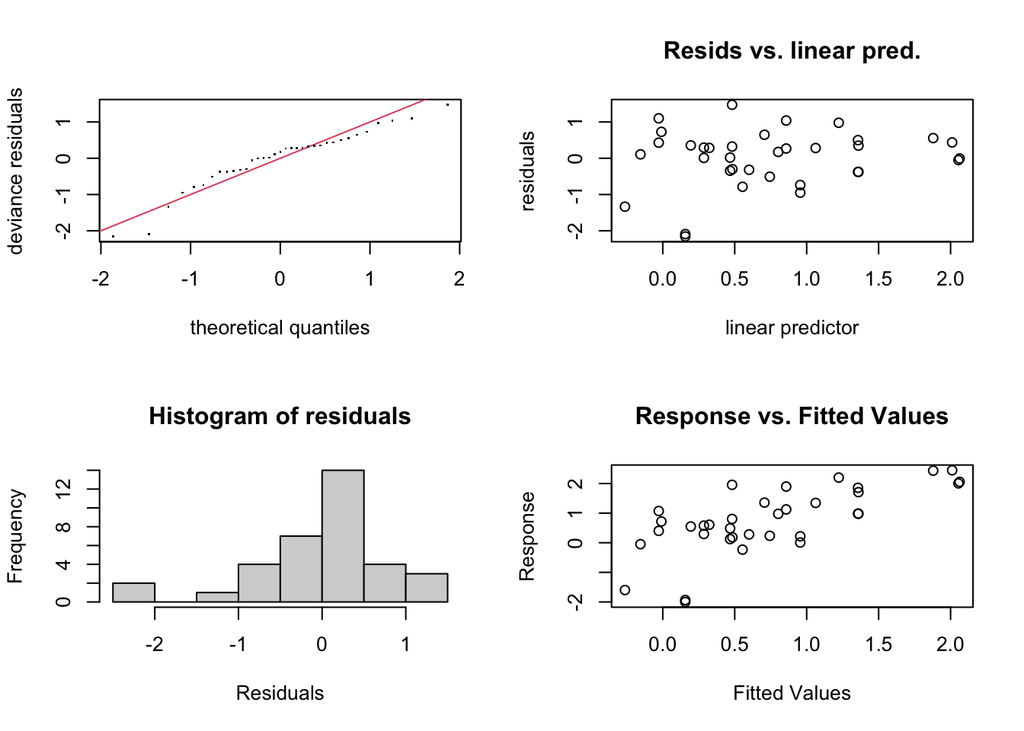

```
##
## Method: REML   Optimizer: outer newton
## full convergence after 12 iterations.
## Gradient range [-1.874076e-05,1.700081e-05]
## (score 48.87859 & scale 0.7261729).
## Hessian positive definite, eigenvalue range [5.086802e-07,17.07691].
## Model rank =  28 / 28
##
## Basis dimension (k) checking results. Low p-value (k-index<1) may
## indicate that k is too low, especially if edf is close to k'.
##
##                                      k'   edf k-index p-value
## s(sst_scale)                      9.000 1.661    0.72   0.020 *
## s(norm_openness_scale)            9.000 0.865    0.70   0.040 *
## s(mean_rec_boat_counts_2km_scale) 9.000 1.547    0.79   0.085 .
## ---
## Signif. codes:  0 '***' 0.001 '**' 0.01 '*' 0.05 '.' 0.1 ' ' 1
```

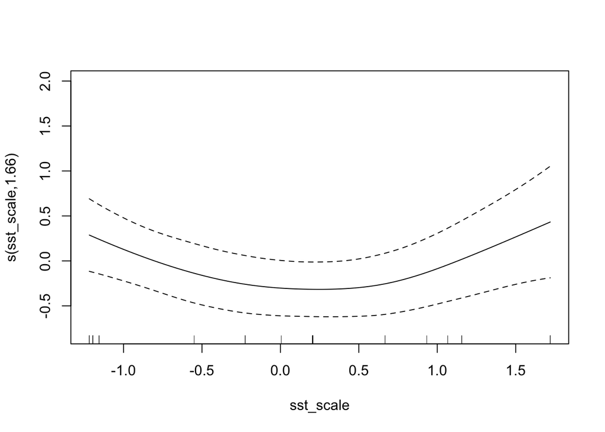

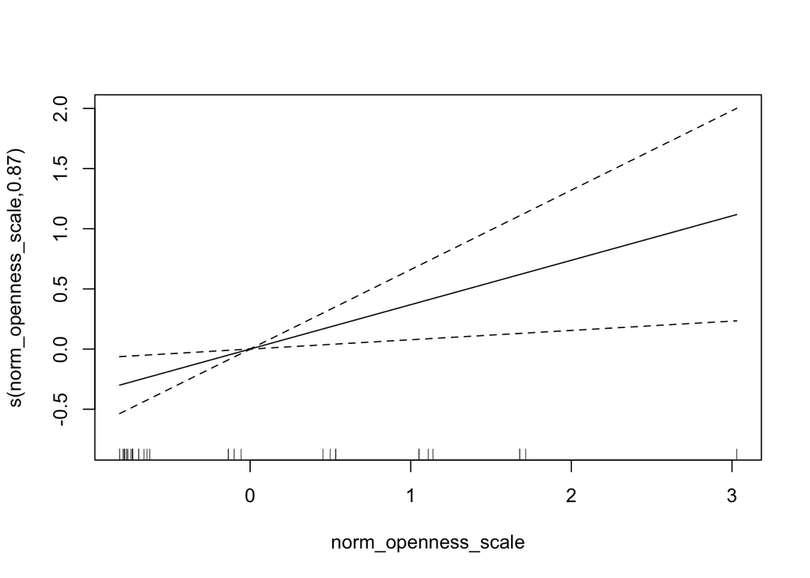

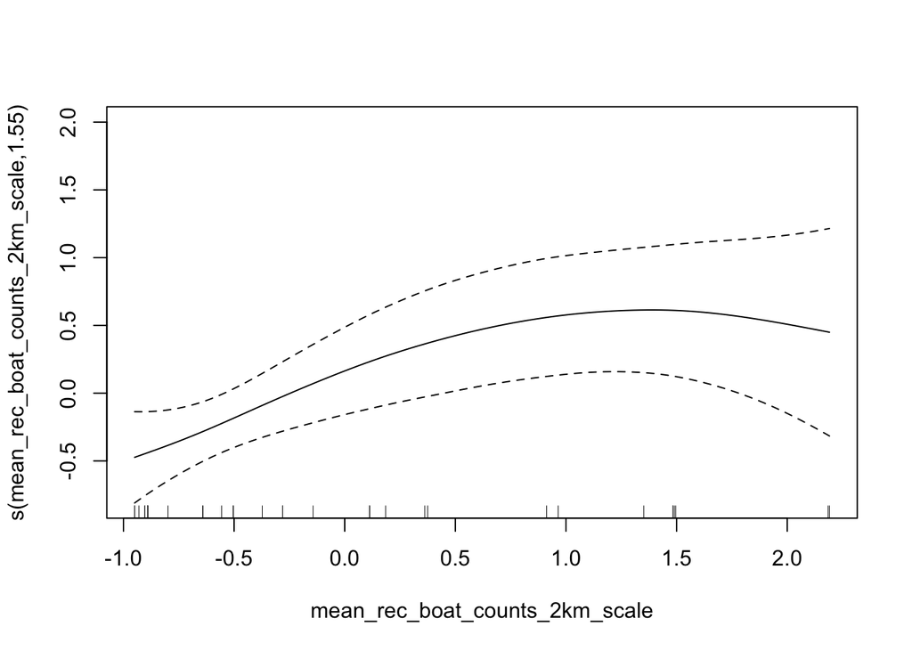

```
##
## Family: gaussian
## Link function: identity
##
## Formula:
## urch_sn_ratio ~ s(sst_scale) + s(norm_openness_scale) + s(mean_rec_boat_counts_2km_scale)
##
## Parametric coefficients:
##             Estimate Std. Error t value Pr(>|t|)
## (Intercept)   0.7446     0.1440   5.169 1.45e-05 ***
## ---
## Signif. codes:  0 '***' 0.001 '**' 0.01 '*' 0.05 '.' 0.1 ' ' 1
##
## Approximate significance of smooth terms:
##                                      edf Ref.df     F p-value
## s(sst_scale)                      1.6606      9 0.579 0.04840 *
## s(norm_openness_scale)            0.8651      9 0.712 0.00888 **
## s(mean_rec_boat_counts_2km_scale) 1.5468      9 0.978 0.00634 **
## ---
## Signif. codes:  0 '***' 0.001 '**' 0.01 '*' 0.05 '.' 0.1 ' ' 1
##
## R-sq.(adj) =  0.406   Deviance explained = 47.7%
## -REML = 48.879  Scale est. = 0.72617   n = 35
```

##### Testing the residuals for autocorrelation

```
##
##  Moran I test under randomisation
##
## data:  residuals_total_mod_2km_no_app_hours
## weights: lw
## n reduced by no-neighbour observations
##
## Moran I statistic standard deviate = 2.0235, p-value = 0.02151
## alternative hypothesis: greater
## sample estimates:
## Moran I statistic       Expectation          Variance
##        0.56238797       -0.05882353        0.09424372
```

It appears that the residuals are autocorrelated. Will need to address this.

##### Testing the model for concurvity

```
##          para s(sst_scale) s(norm_openness_scale)
## worst       1    1.0000000              1.0000000
## observed    1    0.8298830              0.6943684
## estimate    1    0.7394701              0.7903026
##          s(mean_rec_boat_counts_2km_scale)
## worst                            1.0000000
## observed                         0.9015884
## estimate                         0.8013765
```

Some of the variables appear to still have high concurvity scores in the worst case, but confidence intervals seem stable for the model plots.

### Building GAMs with averaged points to test the effects on the urchin to snail ratio (without mean apparent fishing hours)

The idea of averaging the transects at the same sites is to account for the spatial autocorrelation.

#### Model with 1km recreational boats and avg transects (no app hours)

```r
total_mod_1km_avg_no_app_hours <- gam(urch_sn_ratio_avg ~ s(sst_scale) +
                   s(norm_openness_scale) +
                   s(mean_rec_boat_counts_1km_scale),
               data = env_mod_data_avg,
               family = gaussian(link = "identity"),
               method = 'REML',
               select = TRUE)
```

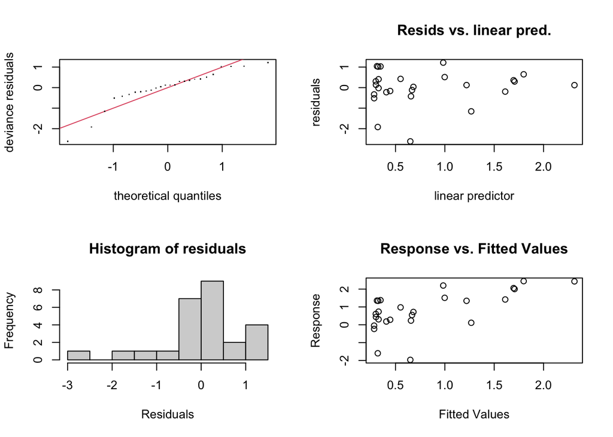

```
##
## Method: REML   Optimizer: outer newton
## full convergence after 19 iterations.
## Gradient range [-4.757836e-06,2.100037e-05]
## (score 35.69224 & scale 0.7888252).
## Hessian positive definite, eigenvalue range [3.428542e-07,12.52193].
## Model rank =  28 / 28
##
## Basis dimension (k) checking results. Low p-value (k-index<1) may
## indicate that k is too low, especially if edf is close to k'.
##
##                                         k'      edf k-index p-value
## s(sst_scale)                      9.00e+00 2.31e-05    1.07    0.60
## s(norm_openness_scale)            9.00e+00 9.09e-01    1.10    0.63
## s(mean_rec_boat_counts_1km_scale) 9.00e+00 4.90e-01    1.17    0.81
```

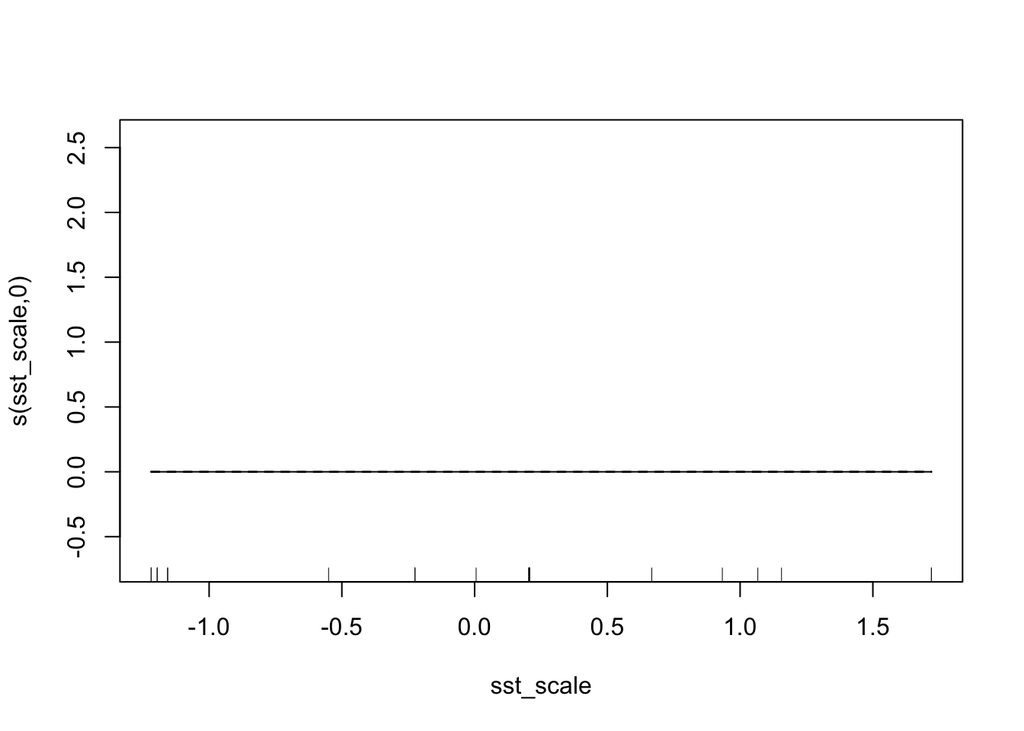

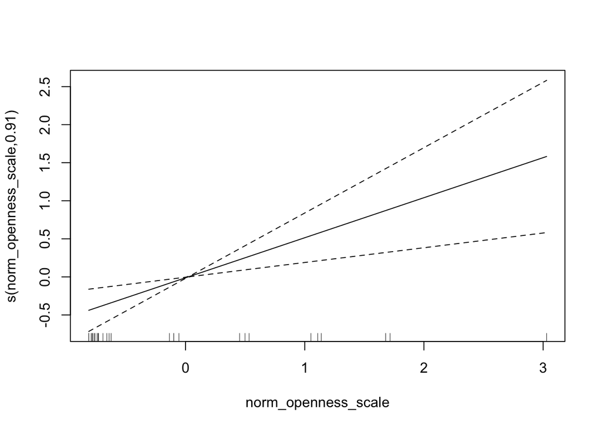

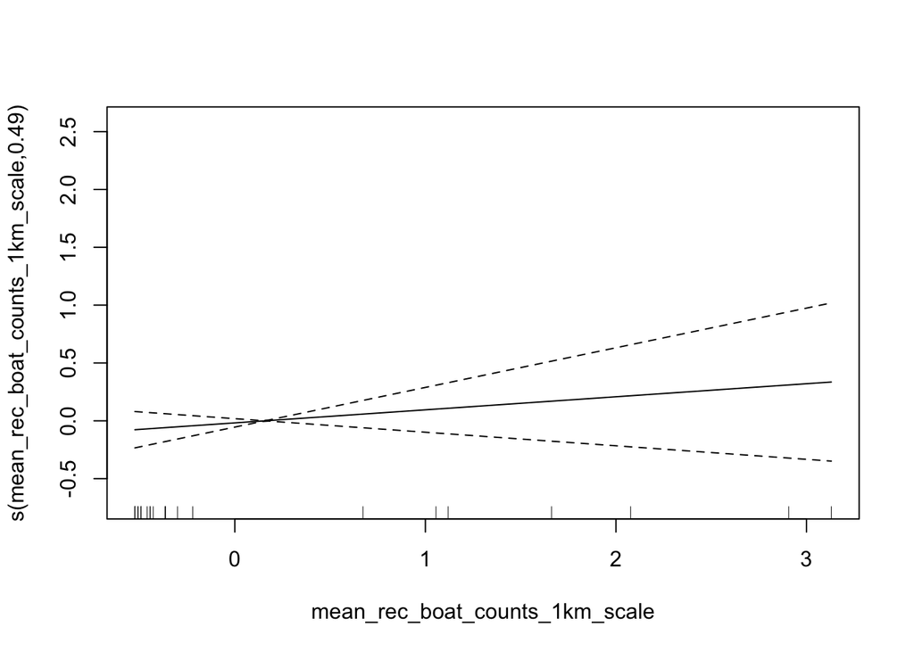

```
##
## Family: gaussian
## Link function: identity
##
## Formula:
## urch_sn_ratio_avg ~ s(sst_scale) + s(norm_openness_scale) + s(mean_rec_boat_counts_1km_scale)
##
## Parametric coefficients:
##             Estimate Std. Error t value Pr(>|t|)
## (Intercept)   0.7994     0.1742   4.589 0.000122 ***
## ---
## Signif. codes:  0 '***' 0.001 '**' 0.01 '*' 0.05 '.' 0.1 ' ' 1
##
## Approximate significance of smooth terms:
##                                         edf Ref.df     F p-value
## s(sst_scale)                      2.311e-05      9 0.000 0.38247
## s(norm_openness_scale)            9.092e-01      9 1.113 0.00265 **
## s(mean_rec_boat_counts_1km_scale) 4.905e-01      9 0.107 0.17268
## ---
## Signif. codes:  0 '***' 0.001 '**' 0.01 '*' 0.05 '.' 0.1 ' ' 1
##
## R-sq.(adj) =  0.335   Deviance explained = 37.2%
## -REML = 35.692  Scale est. = 0.78883   n = 26
```

##### Testing the residuals for autocorrelation

```
##
##  Moran I test under randomisation
##
## data:  residuals_total_mod_1km_avg_no_app_hours
## weights: lw_avg
## n reduced by no-neighbour observations
##
## Moran I statistic standard deviate = 0.40153, p-value = 0.344
## alternative hypothesis: greater
## sample estimates:
## Moran I statistic       Expectation          Variance
##        0.01252044       -0.11111111        0.09480090
```

No evidence of autocorrelation of the residuals.

##### Testing the model for concurvity

```
## $worst
##                                           para s(sst_scale)
## para                              1.000000e+00 2.111799e-24
## s(sst_scale)                      2.106192e-24 1.000000e+00
## s(norm_openness_scale)            2.630097e-23 9.517659e-01
## s(mean_rec_boat_counts_1km_scale) 1.458459e-15 6.631493e-01
##                                   s(norm_openness_scale)
## para                                        2.633319e-23
## s(sst_scale)                                9.517659e-01
## s(norm_openness_scale)                      1.000000e+00
## s(mean_rec_boat_counts_1km_scale)           9.955954e-01
##                                   s(mean_rec_boat_counts_1km_scale)
## para                                                   1.458459e-15
## s(sst_scale)                                           6.631493e-01
## s(norm_openness_scale)                                 9.955954e-01
## s(mean_rec_boat_counts_1km_scale)                      1.000000e+00
##
## $observed
##                                           para s(sst_scale)
## para                              1.000000e+00 6.300116e-30
## s(sst_scale)                      2.106192e-24 1.000000e+00
## s(norm_openness_scale)            2.630097e-23 5.509673e-01
## s(mean_rec_boat_counts_1km_scale) 1.458459e-15 4.154746e-01
##                                   s(norm_openness_scale)
## para                                        1.895541e-33
## s(sst_scale)                                4.948959e-01
## s(norm_openness_scale)                      1.000000e+00
## s(mean_rec_boat_counts_1km_scale)           3.846835e-01
##                                   s(mean_rec_boat_counts_1km_scale)
## para                                                   2.868134e-32
## s(sst_scale)                                           4.254995e-01
## s(norm_openness_scale)                                 5.962759e-01
## s(mean_rec_boat_counts_1km_scale)                      1.000000e+00
##
## $estimate
##                                           para s(sst_scale)
## para                              1.000000e+00 3.685004e-28
## s(sst_scale)                      2.106192e-24 1.000000e+00
## s(norm_openness_scale)            2.630097e-23 4.468583e-01
## s(mean_rec_boat_counts_1km_scale) 1.458459e-15 2.496121e-01
##                                   s(norm_openness_scale)
## para                                        7.676177e-27
## s(sst_scale)                                4.811534e-01
## s(norm_openness_scale)                      1.000000e+00
## s(mean_rec_boat_counts_1km_scale)           3.233170e-01
##                                   s(mean_rec_boat_counts_1km_scale)
## para                                                   9.544174e-18
## s(sst_scale)                                           4.144446e-01
## s(norm_openness_scale)                                 6.891063e-01
## s(mean_rec_boat_counts_1km_scale)                      1.000000e+00
```

Some of the variables appear to still have high concurvity scores in the worst case, but confidence intervals seem stable for the model plots.

#### Model with 1.5km recreational boats and avg transects (no app hours)

```r
total_mod_1.5km_avg_no_app_hours <- gam(urch_sn_ratio_avg ~ s(sst_scale) +
                   s(norm_openness_scale) +
                   s(mean_rec_boat_counts_1.5km_scale),
               data = env_mod_data_avg,
               family = gaussian(link = "identity"),
               method = 'REML',
               select = TRUE)
```

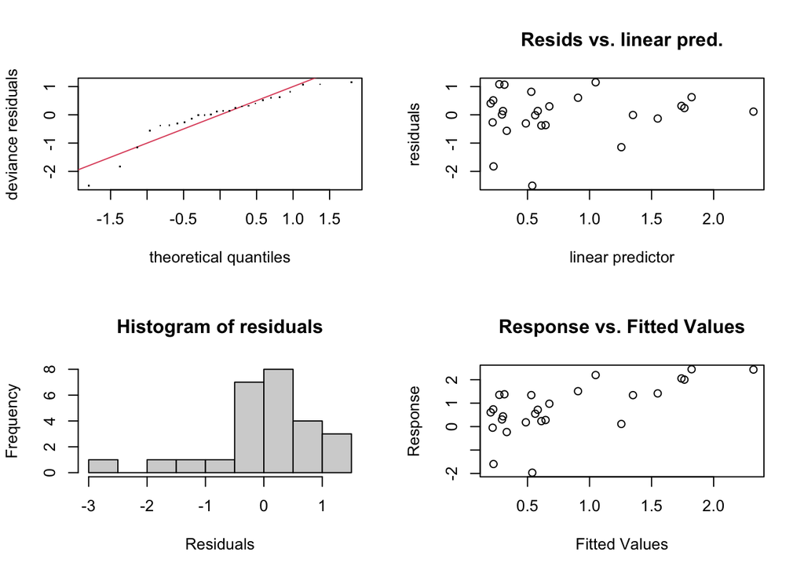

```
##
## Method: REML   Optimizer: outer newton
## full convergence after 19 iterations.
## Gradient range [-1.541358e-05,1.088929e-05]
## (score 35.52545 & scale 0.7558857).
## Hessian positive definite, eigenvalue range [3.343055e-07,12.52759].
## Model rank =  28 / 28
##
## Basis dimension (k) checking results. Low p-value (k-index<1) may
## indicate that k is too low, especially if edf is close to k'.
##
##                                        k'   edf k-index p-value
## s(sst_scale)                        9.000 0.364    1.07    0.58
## s(norm_openness_scale)              9.000 0.909    1.10    0.63
## s(mean_rec_boat_counts_1.5km_scale) 9.000 0.622    1.05    0.60
```

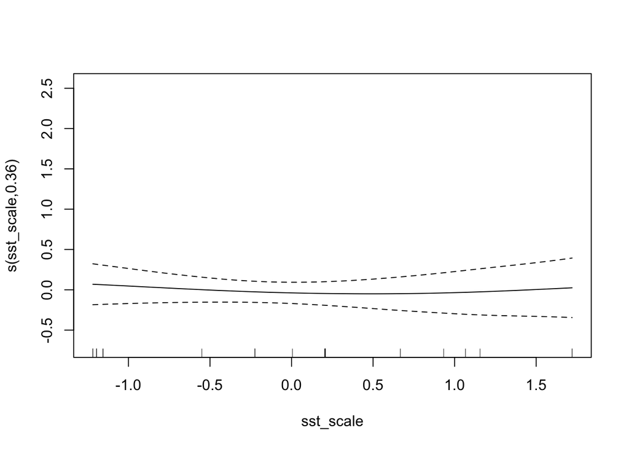

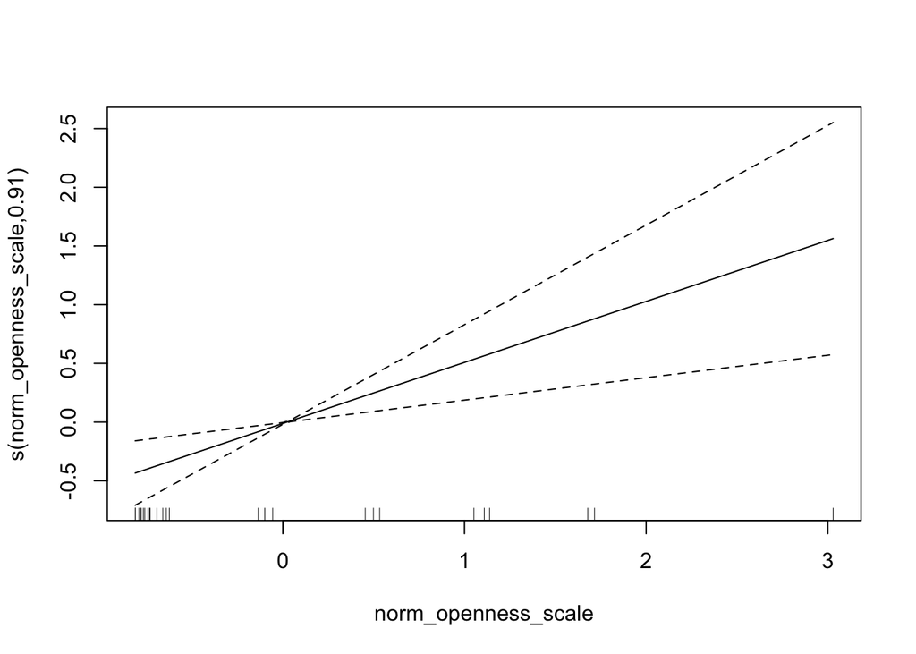

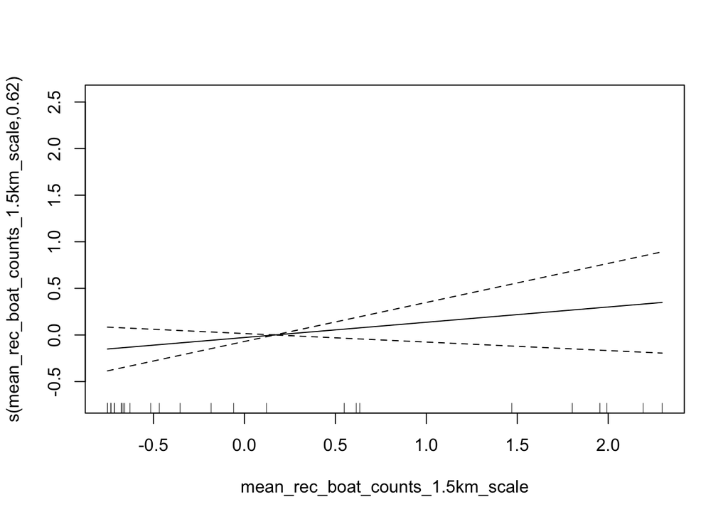

```
##
## Family: gaussian
## Link function: identity
##
## Formula:
## urch_sn_ratio_avg ~ s(sst_scale) + s(norm_openness_scale) + s(mean_rec_boat_counts_1.5km_scale)
##
## Parametric coefficients:
##             Estimate Std. Error t value Pr(>|t|)
## (Intercept)   0.7994     0.1705   4.688    1e-04 ***
## ---
## Signif. codes:  0 '***' 0.001 '**' 0.01 '*' 0.05 '.' 0.1 ' ' 1
##
## Approximate significance of smooth terms:
##                                        edf Ref.df     F p-value
## s(sst_scale)                        0.3635      9 0.048 0.30872
## s(norm_openness_scale)              0.9092      9 1.112 0.00252 **
## s(mean_rec_boat_counts_1.5km_scale) 0.6224      9 0.183 0.11492
## ---
## Signif. codes:  0 '***' 0.001 '**' 0.01 '*' 0.05 '.' 0.1 ' ' 1
##
## R-sq.(adj) =  0.363   Deviance explained = 41.1%
## -REML = 35.525  Scale est. = 0.75589   n = 26
```

##### Testing the residuals for autocorrelation

```
##
##  Moran I test under randomisation
##
## data:  residuals_total_mod_1.5km_avg_no_app_hours
## weights: lw_avg
## n reduced by no-neighbour observations
##
## Moran I statistic standard deviate = 0.43676, p-value = 0.3311
## alternative hypothesis: greater
## sample estimates:
## Moran I statistic       Expectation          Variance
##        0.02806578       -0.11111111        0.10154367
```

No evidence of autocorrelation of the residuals.

##### Testing the model for concurvity

```
## $worst
##                                             para s(sst_scale)
## para                                1.000000e+00 2.111799e-24
## s(sst_scale)                        2.106192e-24 1.000000e+00
## s(norm_openness_scale)              2.630097e-23 9.517659e-01
## s(mean_rec_boat_counts_1.5km_scale) 1.111302e-17 9.316319e-01
##                                     s(norm_openness_scale)
## para                                          2.633319e-23
## s(sst_scale)                                  9.517659e-01
## s(norm_openness_scale)                        1.000000e+00
## s(mean_rec_boat_counts_1.5km_scale)           8.573071e-01
##                                     s(mean_rec_boat_counts_1.5km_scale)
## para                                                       1.111301e-17
## s(sst_scale)                                               9.316319e-01
## s(norm_openness_scale)                                     8.573071e-01
## s(mean_rec_boat_counts_1.5km_scale)                        1.000000e+00
##
## $observed
##                                             para s(sst_scale)
## para                                1.000000e+00 2.734738e-30
## s(sst_scale)                        2.106192e-24 1.000000e+00
## s(norm_openness_scale)              2.630097e-23 5.195980e-01
## s(mean_rec_boat_counts_1.5km_scale) 1.111302e-17 2.032002e-01
##                                     s(norm_openness_scale)
## para                                          1.893362e-33
## s(sst_scale)                                  4.948962e-01
## s(norm_openness_scale)                        1.000000e+00
## s(mean_rec_boat_counts_1.5km_scale)           4.503770e-01
##                                     s(mean_rec_boat_counts_1.5km_scale)
## para                                                       1.264250e-34
## s(sst_scale)                                               4.733751e-01
## s(norm_openness_scale)                                     4.284373e-01
## s(mean_rec_boat_counts_1.5km_scale)                        1.000000e+00
##
## $estimate
##                                             para s(sst_scale)
## para                                1.000000e+00 3.685004e-28
## s(sst_scale)                        2.106192e-24 1.000000e+00
## s(norm_openness_scale)              2.630097e-23 4.468583e-01
## s(mean_rec_boat_counts_1.5km_scale) 1.111302e-17 2.233171e-01
##                                     s(norm_openness_scale)
## para                                          7.676177e-27
## s(sst_scale)                                  4.811534e-01
## s(norm_openness_scale)                        1.000000e+00
## s(mean_rec_boat_counts_1.5km_scale)           4.581371e-01
##                                     s(mean_rec_boat_counts_1.5km_scale)
## para                                                       3.711270e-21
## s(sst_scale)                                               4.448882e-01
## s(norm_openness_scale)                                     4.252366e-01
## s(mean_rec_boat_counts_1.5km_scale)                        1.000000e+00
```

Some of the variables appear to still have high concurvity scores in the worst case, but confidence intervals seem stable for the model plots.

#### Model with 2km recreational boats and avg transects (no mean app hours)

```r
total_mod_2km_avg_no_app_hours <- gam(urch_sn_ratio_avg ~ s(sst_scale) +
                   s(norm_openness_scale) +
                   s(mean_rec_boat_counts_2km_scale),
               data = env_mod_data_avg,
               family = gaussian(link = "identity"),
               method = 'REML',
               select = TRUE)
```

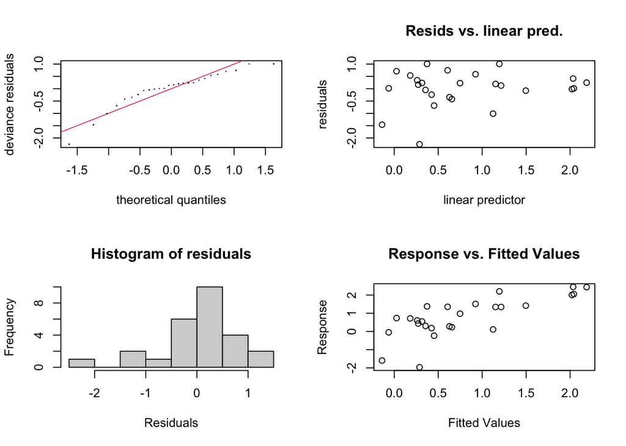

```
##
## Method: REML   Optimizer: outer newton
## full convergence after 14 iterations.
## Gradient range [-1.538687e-05,4.225627e-06]
## (score 34.64154 & scale 0.6206803).
## Hessian positive definite, eigenvalue range [9.012919e-07,12.57241].
## Model rank =  28 / 28
##
## Basis dimension (k) checking results. Low p-value (k-index<1) may
## indicate that k is too low, especially if edf is close to k'.
##
##                                      k'   edf k-index p-value
## s(sst_scale)                      9.000 1.299    1.10    0.63
## s(norm_openness_scale)            9.000 0.898    1.13    0.70
## s(mean_rec_boat_counts_2km_scale) 9.000 1.325    1.09    0.67
```

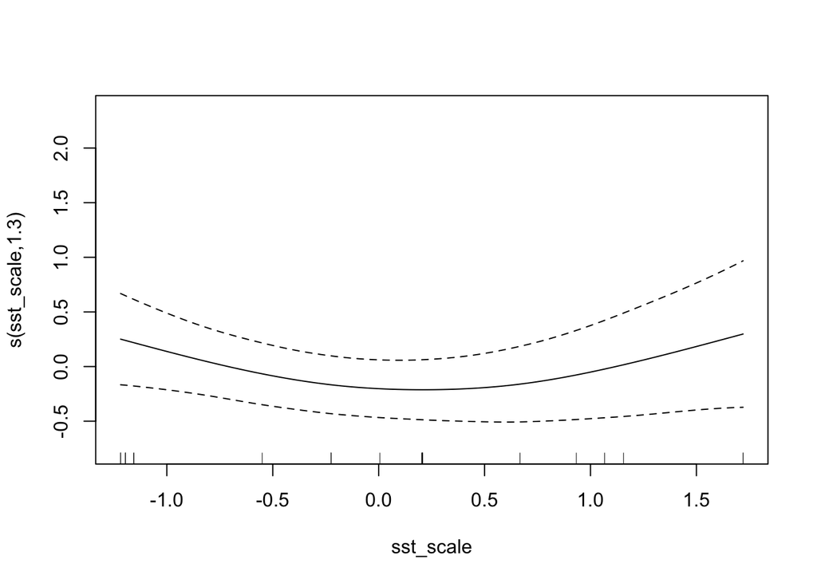

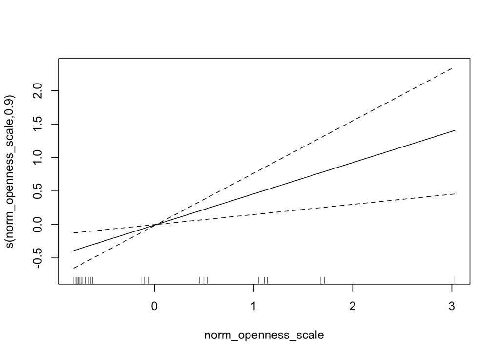

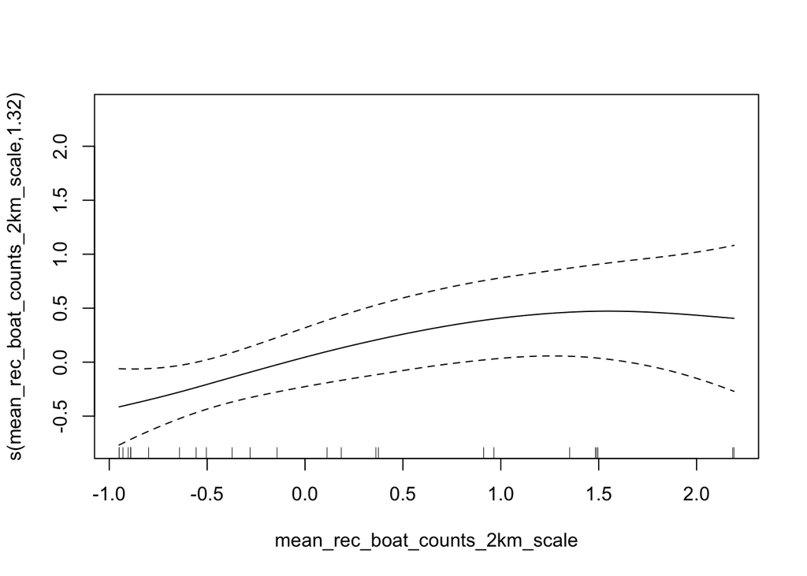

```
##
## Family: gaussian
## Link function: identity
##
## Formula:
## urch_sn_ratio_avg ~ s(sst_scale) + s(norm_openness_scale) + s(mean_rec_boat_counts_2km_scale)
##
## Parametric coefficients:
##             Estimate Std. Error t value Pr(>|t|)
## (Intercept)   0.7994     0.1545   5.174 3.72e-05 ***
## ---
## Signif. codes:  0 '***' 0.001 '**' 0.01 '*' 0.05 '.' 0.1 ' ' 1
##
## Approximate significance of smooth terms:
##                                      edf Ref.df     F p-value
## s(sst_scale)                      1.2988      9 0.306 0.13401
## s(norm_openness_scale)            0.8976      9 0.974 0.00392 **
## s(mean_rec_boat_counts_2km_scale) 1.3246      9 0.655 0.02217 *
## ---
## Signif. codes:  0 '***' 0.001 '**' 0.01 '*' 0.05 '.' 0.1 ' ' 1
##
## R-sq.(adj) =  0.477   Deviance explained =   55%
## -REML = 34.642  Scale est. = 0.62068   n = 26
```

##### Testing the residuals for autocorrelation

```
##
##  Moran I test under randomisation
##
## data:  residuals_total_mod_2km_avg_no_app_hours
## weights: lw_avg
## n reduced by no-neighbour observations
##
## Moran I statistic standard deviate = 0.43159, p-value = 0.333
## alternative hypothesis: greater
## sample estimates:
## Moran I statistic       Expectation          Variance
##        0.02321326       -0.11111111        0.09686522
```

No evidence of autocorrelation of the residuals.

##### Testing the model for concurvity

```
## $worst
##                                           para s(sst_scale)
## para                              1.000000e+00 2.111799e-24
## s(sst_scale)                      2.106192e-24 1.000000e+00
## s(norm_openness_scale)            2.630097e-23 9.517659e-01
## s(mean_rec_boat_counts_2km_scale) 9.077705e-17 8.878102e-01
##                                   s(norm_openness_scale)
## para                                        2.633319e-23
## s(sst_scale)                                9.517659e-01
## s(norm_openness_scale)                      1.000000e+00
## s(mean_rec_boat_counts_2km_scale)           8.511249e-01
##                                   s(mean_rec_boat_counts_2km_scale)
## para                                                   9.077710e-17
## s(sst_scale)                                           8.878102e-01
## s(norm_openness_scale)                                 8.511249e-01
## s(mean_rec_boat_counts_2km_scale)                      1.000000e+00
##
## $observed
##                                           para s(sst_scale)
## para                              1.000000e+00 1.545372e-30
## s(sst_scale)                      2.106192e-24 1.000000e+00
## s(norm_openness_scale)            2.630097e-23 4.141406e-01
## s(mean_rec_boat_counts_2km_scale) 9.077705e-17 4.331904e-01
##                                   s(norm_openness_scale)
## para                                        1.893858e-33
## s(sst_scale)                                4.948961e-01
## s(norm_openness_scale)                      1.000000e+00
## s(mean_rec_boat_counts_2km_scale)           2.050347e-01
##                                   s(mean_rec_boat_counts_2km_scale)
## para                                                   1.431588e-22
## s(sst_scale)                                           5.978475e-01
## s(norm_openness_scale)                                 3.805260e-01
## s(mean_rec_boat_counts_2km_scale)                      1.000000e+00
##
## $estimate
##                                           para s(sst_scale)
## para                              1.000000e+00 3.685004e-28
## s(sst_scale)                      2.106192e-24 1.000000e+00
## s(norm_openness_scale)            2.630097e-23 4.468583e-01
## s(mean_rec_boat_counts_2km_scale) 9.077705e-17 2.377109e-01
##                                   s(norm_openness_scale)
## para                                        7.676177e-27
## s(sst_scale)                                4.811534e-01
## s(norm_openness_scale)                      1.000000e+00
## s(mean_rec_boat_counts_2km_scale)           2.359172e-01
##                                   s(mean_rec_boat_counts_2km_scale)
## para                                                   7.190114e-20
## s(sst_scale)                                           5.410720e-01
## s(norm_openness_scale)                                 3.130322e-01
## s(mean_rec_boat_counts_2km_scale)                      1.000000e+00
```

Some of the variables appear to still have high concurvity scores in the worst case, but confidence intervals seem stable for the model plots.

### Building GAMs on urch sn ratio with TOTAL boats observed instead of rec boats fishing

#### Model with 1 km total boats

```r
total_mod_1km_total_boats <- gam(urch_sn_ratio ~ s(sst_scale) +
                   s(norm_openness_scale) +
                   s(mean_total_boat_counts_1km_scale)+
                   s(mean_app_fishing_hours_scale),
               data = env_mod_data,
               family = gaussian(link = "identity"),
               method = 'REML',
               select = TRUE)
```

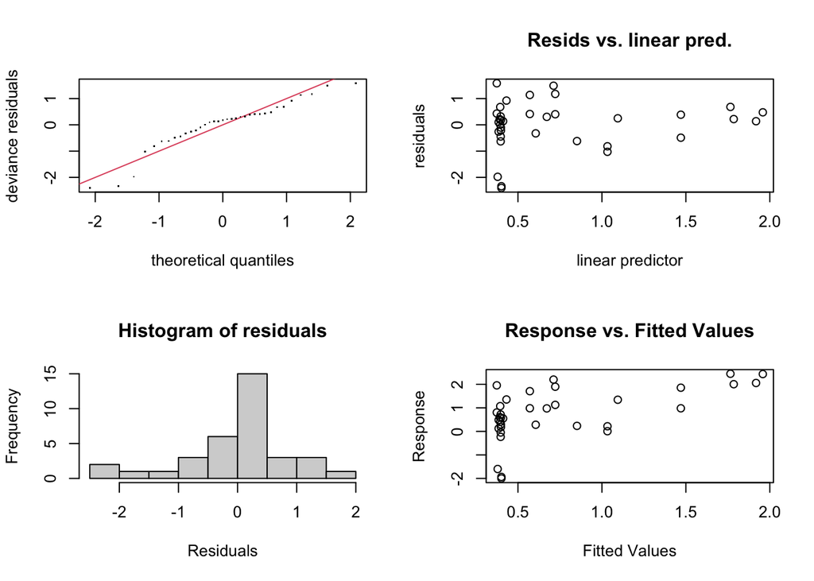

```
##
## Method: REML   Optimizer: outer newton
## full convergence after 14 iterations.
## Gradient range [-5.555445e-05,0.0001239979]
## (score 50.53931 & scale 0.9075666).
## Hessian positive definite, eigenvalue range [1.902977e-06,17.04531].
## Model rank =  37 / 37
##
## Basis dimension (k) checking results. Low p-value (k-index<1) may
## indicate that k is too low, especially if edf is close to k'.
##
##                                           k'      edf k-index p-value
## s(sst_scale)                        9.00e+00 2.25e-04    0.76   0.045 *
## s(norm_openness_scale)              9.00e+00 1.60e+00    0.69   0.025 *
## s(mean_total_boat_counts_1km_scale) 9.00e+00 6.82e-01    0.71   0.055 .
## s(mean_app_fishing_hours_scale)     9.00e+00 1.93e-05    0.75   0.050 *
## ---
## Signif. codes:  0 '***' 0.001 '**' 0.01 '*' 0.05 '.' 0.1 ' ' 1
```

```
##                           (Intercept)                        s(sst_scale).1
##                          7.445666e-01                          1.437847e-05
##                        s(sst_scale).2                        s(sst_scale).3
##                         -1.077650e-05                         -4.887332e-06
##                        s(sst_scale).4                        s(sst_scale).5
##                         -1.118258e-05                          1.083032e-05
##                        s(sst_scale).6                        s(sst_scale).7
##                          9.390068e-06                          7.599047e-06
##                        s(sst_scale).8                        s(sst_scale).9
##                         -6.005078e-05                         -2.733462e-07
##              s(norm_openness_scale).1              s(norm_openness_scale).2
##                         -3.581637e-01                          2.257812e-01
##              s(norm_openness_scale).3              s(norm_openness_scale).4
##                          8.779939e-02                         -1.124142e-01
##              s(norm_openness_scale).5              s(norm_openness_scale).6
##                          2.796169e-02                         -6.913296e-02
##              s(norm_openness_scale).7              s(norm_openness_scale).8
##                          6.568107e-02                         -4.540538e-02
##              s(norm_openness_scale).9 s(mean_total_boat_counts_1km_scale).1
##                          2.384118e-05                          5.052936e-07
## s(mean_total_boat_counts_1km_scale).2 s(mean_total_boat_counts_1km_scale).3
##                          2.918901e-06                         -1.094735e-06
## s(mean_total_boat_counts_1km_scale).4 s(mean_total_boat_counts_1km_scale).5
##                          1.882536e-06                          9.994585e-07
## s(mean_total_boat_counts_1km_scale).6 s(mean_total_boat_counts_1km_scale).7
##                         -2.101243e-06                         -2.016844e-06
## s(mean_total_boat_counts_1km_scale).8 s(mean_total_boat_counts_1km_scale).9
##                          1.080231e-05                          2.050767e-01
##     s(mean_app_fishing_hours_scale).1     s(mean_app_fishing_hours_scale).2
##                         -7.208418e-07                          3.350197e-07
##     s(mean_app_fishing_hours_scale).3     s(mean_app_fishing_hours_scale).4
##                         -4.446425e-07                         -3.569590e-07
##     s(mean_app_fishing_hours_scale).5     s(mean_app_fishing_hours_scale).6
##                          3.744351e-07                          4.120258e-07
##     s(mean_app_fishing_hours_scale).7     s(mean_app_fishing_hours_scale).8
##                          4.060955e-07                         -2.012472e-06
##     s(mean_app_fishing_hours_scale).9
##                         -7.539014e-07
```

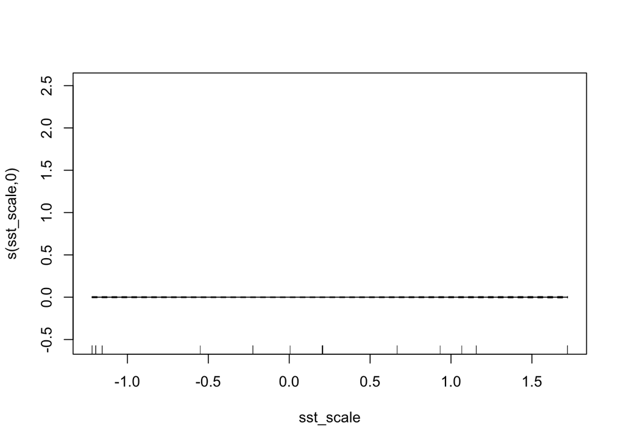

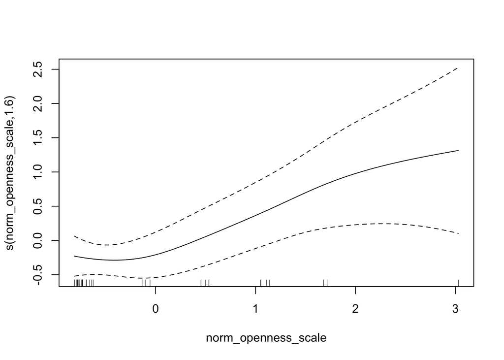

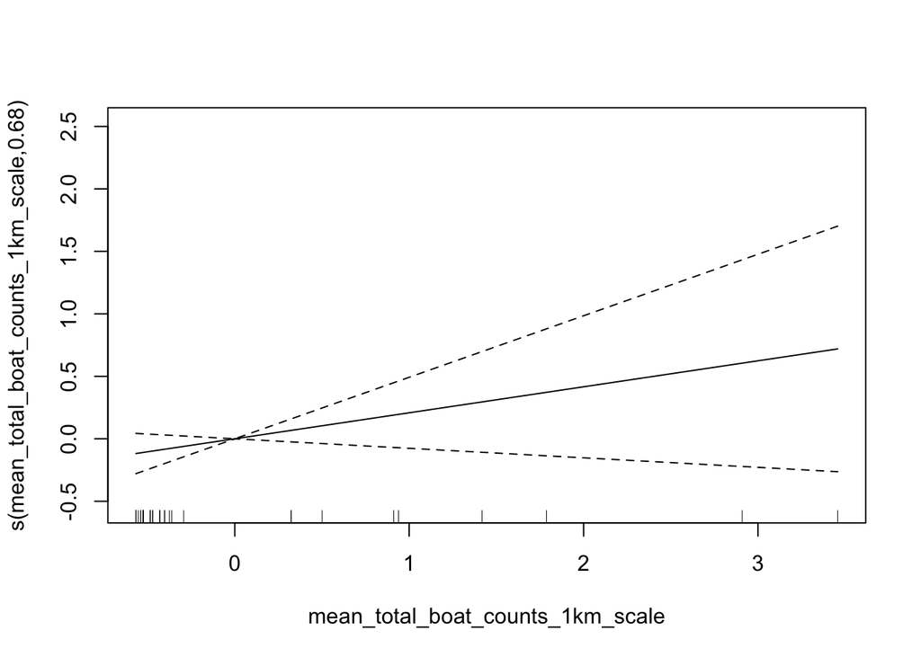

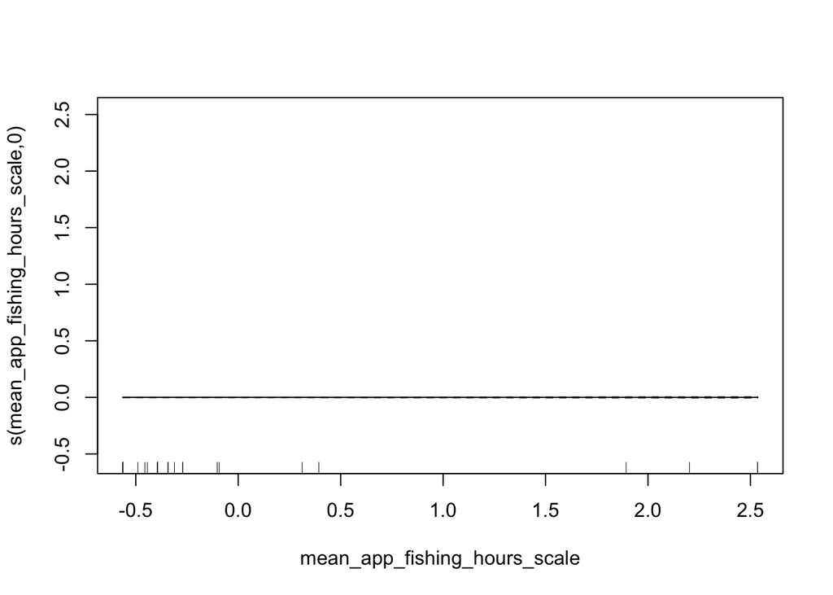

```
##
## Family: gaussian
## Link function: identity
##
## Formula:
## urch_sn_ratio ~ s(sst_scale) + s(norm_openness_scale) + s(mean_total_boat_counts_1km_scale) +
##     s(mean_app_fishing_hours_scale)
##
## Parametric coefficients:
##             Estimate Std. Error t value Pr(>|t|)
## (Intercept)   0.7446     0.1610   4.624 6.01e-05 ***
## ---
## Signif. codes:  0 '***' 0.001 '**' 0.01 '*' 0.05 '.' 0.1 ' ' 1
##
## Approximate significance of smooth terms:
##                                           edf Ref.df     F p-value
## s(sst_scale)                        2.254e-04      9 0.000  0.4119
## s(norm_openness_scale)              1.596e+00      9 0.871  0.0113 *
## s(mean_total_boat_counts_1km_scale) 6.819e-01      9 0.238  0.0823 .
## s(mean_app_fishing_hours_scale)     1.928e-05      9 0.000  0.6959
## ---
## Signif. codes:  0 '***' 0.001 '**' 0.01 '*' 0.05 '.' 0.1 ' ' 1
##
## R-sq.(adj) =  0.257   Deviance explained = 30.7%
## -REML = 50.539  Scale est. = 0.90757   n = 35
```

When using total boats that term seems to have more of an effect than rec boats fishing only.

##### Testing the residuals for autocorrelation

```
##
##  Moran I test under randomisation
##
## data:  residuals_total_mod_1km_total_boats
## weights: lw
## n reduced by no-neighbour observations
##
## Moran I statistic standard deviate = 1.9678, p-value = 0.02455
## alternative hypothesis: greater
## sample estimates:
## Moran I statistic       Expectation          Variance
##        0.54460601       -0.05882353        0.09403463
```

```
##
##  Moran I test under randomisation
##
## data:  residuals_total_mod_1km_total_boats
## weights: lw_inverse
##
## Moran I statistic standard deviate = 3.5147, p-value = 0.0002201
## alternative hypothesis: greater
## sample estimates:
## Moran I statistic       Expectation          Variance
##        0.55611702       -0.02941176        0.02775339
```

It appears that the residuals are autocorrelated. Will need to address this.

##### Testing the model for concurvity

```
## $worst
##                                             para s(sst_scale)
## para                                1.000000e+00 4.176841e-24
## s(sst_scale)                        4.182745e-24 1.000000e+00
## s(norm_openness_scale)              1.365135e-17 9.527043e-01
## s(mean_total_boat_counts_1km_scale) 8.105300e-18 8.466783e-01
## s(mean_app_fishing_hours_scale)     6.545436e-17 9.996134e-01
##                                     s(norm_openness_scale)
## para                                          1.365142e-17
## s(sst_scale)                                  9.527043e-01
## s(norm_openness_scale)                        1.000000e+00
## s(mean_total_boat_counts_1km_scale)           9.705147e-01
## s(mean_app_fishing_hours_scale)               8.987165e-01
##                                     s(mean_total_boat_counts_1km_scale)
## para                                                       8.105327e-18
## s(sst_scale)                                               8.466783e-01
## s(norm_openness_scale)                                     9.705147e-01
## s(mean_total_boat_counts_1km_scale)                        1.000000e+00
## s(mean_app_fishing_hours_scale)                            9.999935e-01
##                                     s(mean_app_fishing_hours_scale)
## para                                                   6.545414e-17
## s(sst_scale)                                           9.996134e-01
## s(norm_openness_scale)                                 8.987165e-01
## s(mean_total_boat_counts_1km_scale)                    9.999935e-01
## s(mean_app_fishing_hours_scale)                        1.000000e+00
##
## $observed
##                                             para s(sst_scale)
## para                                1.000000e+00 9.507286e-31
## s(sst_scale)                        4.182745e-24 1.000000e+00
## s(norm_openness_scale)              1.365135e-17 4.955853e-01
## s(mean_total_boat_counts_1km_scale) 8.105300e-18 4.189201e-01
## s(mean_app_fishing_hours_scale)     6.545436e-17 4.846526e-01
##                                     s(norm_openness_scale)
## para                                          5.433761e-24
## s(sst_scale)                                  5.492663e-01
## s(norm_openness_scale)                        1.000000e+00
## s(mean_total_boat_counts_1km_scale)           2.146452e-01
## s(mean_app_fishing_hours_scale)               2.019643e-01
##                                     s(mean_total_boat_counts_1km_scale)
```

[output cut: 22 more lines]

```
## s(norm_openness_scale)                        1.000000e+00
## s(mean_total_boat_counts_1km_scale)           2.174107e-01
## s(mean_app_fishing_hours_scale)               1.669555e-01
##                                     s(mean_total_boat_counts_1km_scale)
## para                                                       1.351239e-21
## s(sst_scale)                                               3.391598e-01
## s(norm_openness_scale)                                     6.992369e-01
## s(mean_total_boat_counts_1km_scale)                        1.000000e+00
## s(mean_app_fishing_hours_scale)                            5.831460e-01
##                                     s(mean_app_fishing_hours_scale)
## para                                                   5.634184e-21
## s(sst_scale)                                           4.095968e-01
## s(norm_openness_scale)                                 2.390114e-01
## s(mean_total_boat_counts_1km_scale)                    7.899466e-01
## s(mean_app_fishing_hours_scale)                        1.000000e+00
```

Some of the variables appear to have high concurvity scores in the worst case, but confidence intervals seem stable for the model plots. May need to get rid of the mean apparent fishing hours however. Since the concurvity was very high.

#### Model with 1.5 km total boats

```r
total_mod_1.5km_total_boats <- gam(urch_sn_ratio ~ s(sst_scale) +
                   s(norm_openness_scale) +
                   s(mean_total_boat_counts_1.5km_scale)+
                   s(mean_app_fishing_hours_scale),
               data = env_mod_data,
               family = gaussian(link = "identity"),
               method = 'REML',
               select = TRUE)
```

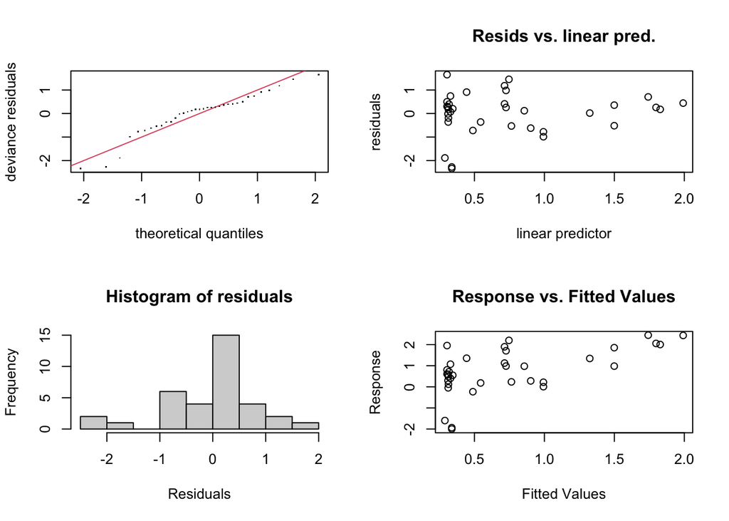

```
##
## Method: REML   Optimizer: outer newton
## full convergence after 12 iterations.
## Gradient range [-6.121114e-05,0.0001377885]
## (score 50.25807 & scale 0.8831975).
## Hessian positive definite, eigenvalue range [8.926756e-07,17.04887].
## Model rank =  37 / 37
##
## Basis dimension (k) checking results. Low p-value (k-index<1) may
## indicate that k is too low, especially if edf is close to k'.
##
##                                             k'      edf k-index p-value
## s(sst_scale)                          9.000000 0.000149    0.74    0.04 *
## s(norm_openness_scale)                9.000000 1.637401    0.68    0.02 *
## s(mean_total_boat_counts_1.5km_scale) 9.000000 0.751001    0.82    0.14
## s(mean_app_fishing_hours_scale)       9.000000 0.000025    0.78    0.06 .
## ---
## Signif. codes:  0 '***' 0.001 '**' 0.01 '*' 0.05 '.' 0.1 ' ' 1
```

```
##                             (Intercept)                          s(sst_scale).1
##                            7.445666e-01                            8.493702e-06
##                          s(sst_scale).2                          s(sst_scale).3
##                           -7.821805e-06                           -3.385548e-06
##                          s(sst_scale).4                          s(sst_scale).5
##                           -8.096642e-06                            7.679020e-06
##                          s(sst_scale).6                          s(sst_scale).7
##                            6.829416e-06                            5.751685e-06
##                          s(sst_scale).8                          s(sst_scale).9
##                           -4.303889e-05                           -1.037919e-07
##                s(norm_openness_scale).1                s(norm_openness_scale).2
##                           -3.721532e-01                            2.257387e-01
##                s(norm_openness_scale).3                s(norm_openness_scale).4
##                            8.647550e-02                           -1.115441e-01
##                s(norm_openness_scale).5                s(norm_openness_scale).6
##                            2.600641e-02                           -6.461849e-02
##                s(norm_openness_scale).7                s(norm_openness_scale).8
##                            6.209071e-02                           -1.265115e-02
##                s(norm_openness_scale).9 s(mean_total_boat_counts_1.5km_scale).1
##                            3.204397e-05                           -3.151231e-06
## s(mean_total_boat_counts_1.5km_scale).2 s(mean_total_boat_counts_1.5km_scale).3
##                           -8.192295e-06                           -2.211470e-08
## s(mean_total_boat_counts_1.5km_scale).4 s(mean_total_boat_counts_1.5km_scale).5
##                            8.145544e-06                            1.816144e-06
## s(mean_total_boat_counts_1.5km_scale).6 s(mean_total_boat_counts_1.5km_scale).7
##                           -7.472019e-06                           -6.036302e-06
## s(mean_total_boat_counts_1.5km_scale).8 s(mean_total_boat_counts_1.5km_scale).9
##                            3.619539e-05                            2.434315e-01
##       s(mean_app_fishing_hours_scale).1       s(mean_app_fishing_hours_scale).2
##                           -2.108333e-06                            9.586628e-07
##       s(mean_app_fishing_hours_scale).3       s(mean_app_fishing_hours_scale).4
##                           -1.333322e-06                           -1.053227e-06
##       s(mean_app_fishing_hours_scale).5       s(mean_app_fishing_hours_scale).6
##                            1.109998e-06                            1.225077e-06
##       s(mean_app_fishing_hours_scale).7       s(mean_app_fishing_hours_scale).8
##                            1.204208e-06                           -6.042450e-06
##       s(mean_app_fishing_hours_scale).9
##                           -1.700526e-07
```

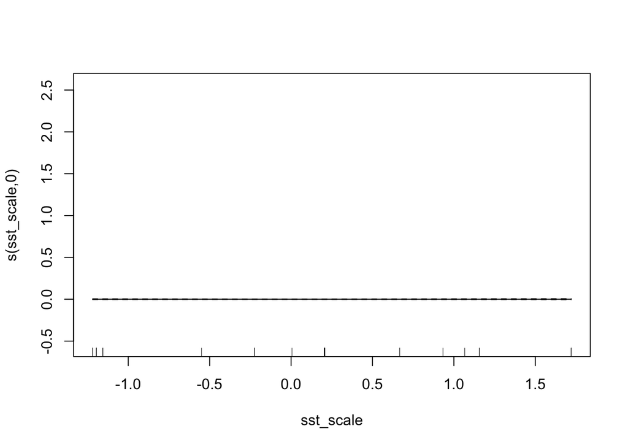

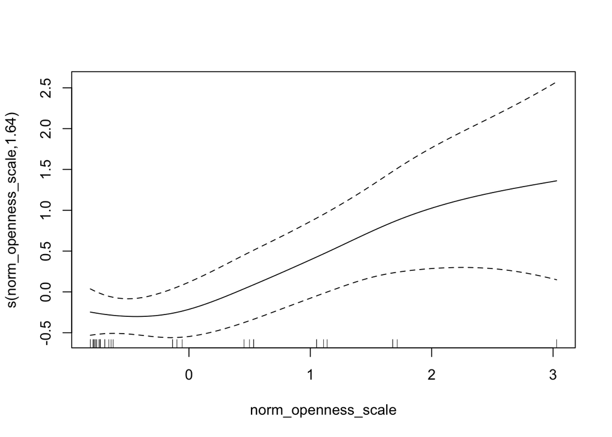

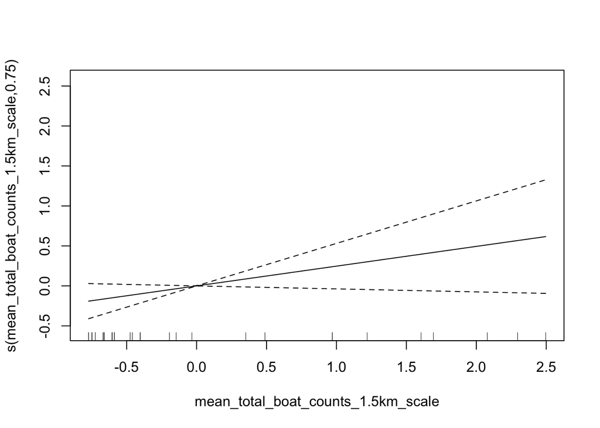

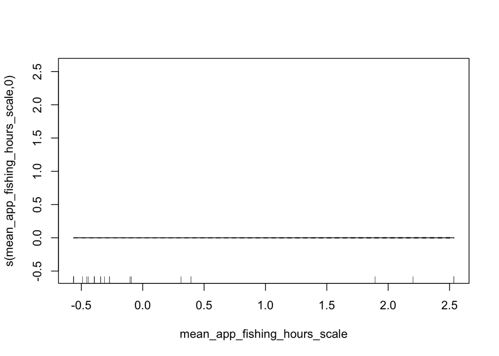

```
##
## Family: gaussian
## Link function: identity
##
## Formula:
## urch_sn_ratio ~ s(sst_scale) + s(norm_openness_scale) + s(mean_total_boat_counts_1.5km_scale) +
##     s(mean_app_fishing_hours_scale)
##
## Parametric coefficients:
##             Estimate Std. Error t value Pr(>|t|)
## (Intercept)   0.7446     0.1589   4.687 5.05e-05 ***
## ---
## Signif. codes:  0 '***' 0.001 '**' 0.01 '*' 0.05 '.' 0.1 ' ' 1
##
## Approximate significance of smooth terms:
##                                             edf Ref.df     F p-value
## s(sst_scale)                          0.0001487      9 0.000 0.36500
## s(norm_openness_scale)                1.6374007      9 0.993 0.00755 **
## s(mean_total_boat_counts_1.5km_scale) 0.7510008      9 0.335 0.05244 .
## s(mean_app_fishing_hours_scale)       0.0000250      9 0.000 0.62884
## ---
## Signif. codes:  0 '***' 0.001 '**' 0.01 '*' 0.05 '.' 0.1 ' ' 1
##
## R-sq.(adj) =  0.277   Deviance explained = 32.8%
## -REML = 50.258  Scale est. = 0.8832    n = 35
```

When using total boats that term seems to have more of an effect than rec boats fishing only.

##### Testing the residuals for autocorrelation

```
##
##  Moran I test under randomisation
##
## data:  residuals_total_mod_1.5km_total_boats
## weights: lw
## n reduced by no-neighbour observations
##
## Moran I statistic standard deviate = 1.9257, p-value = 0.02707
## alternative hypothesis: greater
## sample estimates:
## Moran I statistic       Expectation          Variance
##        0.53528047       -0.05882353        0.09517774
```

```
##
##  Moran I test under randomisation
##
## data:  residuals_total_mod_1.5km_total_boats
## weights: lw_inverse
##
## Moran I statistic standard deviate = 3.4443, p-value = 0.0002863
## alternative hypothesis: greater
## sample estimates:
## Moran I statistic       Expectation          Variance
##        0.54582063       -0.02941176        0.02789203
```

It appears that the residuals are autocorrelated. Will need to address this.

##### Testing the model for concurvity

```
## $worst
##                                               para s(sst_scale)
## para                                  1.000000e+00 4.176841e-24
## s(sst_scale)                          4.182745e-24 1.000000e+00
## s(norm_openness_scale)                1.365135e-17 9.527043e-01
## s(mean_total_boat_counts_1.5km_scale) 5.596186e-21 8.323722e-01
## s(mean_app_fishing_hours_scale)       6.545435e-17 9.996134e-01
##                                       s(norm_openness_scale)
## para                                            1.365142e-17
## s(sst_scale)                                    9.527043e-01
## s(norm_openness_scale)                          1.000000e+00
## s(mean_total_boat_counts_1.5km_scale)           8.910111e-01
## s(mean_app_fishing_hours_scale)                 8.987165e-01
##                                       s(mean_total_boat_counts_1.5km_scale)
## para                                                           5.595431e-21
## s(sst_scale)                                                   8.323722e-01
## s(norm_openness_scale)                                         8.910111e-01
## s(mean_total_boat_counts_1.5km_scale)                          1.000000e+00
## s(mean_app_fishing_hours_scale)                                9.997418e-01
##                                       s(mean_app_fishing_hours_scale)
## para                                                     6.545414e-17
## s(sst_scale)                                             9.996134e-01
## s(norm_openness_scale)                                   8.987165e-01
## s(mean_total_boat_counts_1.5km_scale)                    9.997418e-01
## s(mean_app_fishing_hours_scale)                          1.000000e+00
##
## $observed
##                                               para s(sst_scale)
## para                                  1.000000e+00 4.600411e-31
## s(sst_scale)                          4.182745e-24 1.000000e+00
## s(norm_openness_scale)                1.365135e-17 4.690173e-01
## s(mean_total_boat_counts_1.5km_scale) 5.596186e-21 4.109180e-01
## s(mean_app_fishing_hours_scale)       6.545435e-17 5.385075e-01
##                                       s(norm_openness_scale)
## para                                            5.126642e-24
## s(sst_scale)                                    5.471507e-01
## s(norm_openness_scale)                          1.000000e+00
## s(mean_total_boat_counts_1.5km_scale)           6.048015e-01
## s(mean_app_fishing_hours_scale)                 2.013466e-01
##                                       s(mean_total_boat_counts_1.5km_scale)
```

[output cut: 22 more lines]

```
## s(norm_openness_scale)                          1.000000e+00
## s(mean_total_boat_counts_1.5km_scale)           5.276673e-01
## s(mean_app_fishing_hours_scale)                 1.669555e-01
##                                       s(mean_total_boat_counts_1.5km_scale)
## para                                                           2.727964e-24
## s(sst_scale)                                                   3.833652e-01
## s(norm_openness_scale)                                         4.876233e-01
## s(mean_total_boat_counts_1.5km_scale)                          1.000000e+00
## s(mean_app_fishing_hours_scale)                                5.382138e-01
##                                       s(mean_app_fishing_hours_scale)
## para                                                     5.634184e-21
## s(sst_scale)                                             4.095968e-01
## s(norm_openness_scale)                                   2.390114e-01
## s(mean_total_boat_counts_1.5km_scale)                    6.889321e-01
## s(mean_app_fishing_hours_scale)                          1.000000e+00
```

Some of the variables appear to have high concurvity scores in the worst case, but confidence intervals seem stable for the model plots. May need to get rid of the mean apparent fishing hours however. Since the concurvity was very high.

#### Model with 2 km total boats

```r
total_mod_2km_total_boats <- gam(urch_sn_ratio ~ s(sst_scale) +
                   s(norm_openness_scale) +
                   s(mean_total_boat_counts_2km_scale)+
                   s(mean_app_fishing_hours_scale),
               data = env_mod_data,
               family = gaussian(link = "identity"),
               method = 'REML',
               select = TRUE)
```

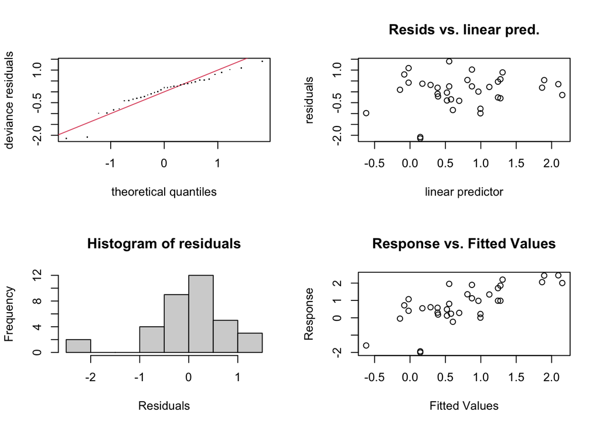

```
##
## Method: REML   Optimizer: outer newton
## full convergence after 15 iterations.
## Gradient range [-4.728002e-05,0.0001247985]
## (score 49.02839 & scale 0.6987028).
## Hessian positive definite, eigenvalue range [1.920494e-06,17.09609].
## Model rank =  37 / 37
##
## Basis dimension (k) checking results. Low p-value (k-index<1) may
## indicate that k is too low, especially if edf is close to k'.
##
##                                        k'   edf k-index p-value
## s(sst_scale)                        9.000 1.776    0.67    0.01 **
## s(norm_openness_scale)              9.000 0.846    0.69    0.03 *
## s(mean_total_boat_counts_2km_scale) 9.000 1.665    0.87    0.16
## s(mean_app_fishing_hours_scale)     9.000 0.484    0.79    0.07 .
## ---
## Signif. codes:  0 '***' 0.001 '**' 0.01 '*' 0.05 '.' 0.1 ' ' 1
```

```
##                           (Intercept)                        s(sst_scale).1
##                          7.445666e-01                          1.640918e-01
##                        s(sst_scale).2                        s(sst_scale).3
##                         -2.760792e-01                         -6.011945e-02
##                        s(sst_scale).4                        s(sst_scale).5
##                         -2.326017e-01                          2.204985e-01
##                        s(sst_scale).6                        s(sst_scale).7
##                          2.186827e-01                          2.093684e-01
##                        s(sst_scale).8                        s(sst_scale).9
##                         -1.227729e+00                          9.657854e-07
##              s(norm_openness_scale).1              s(norm_openness_scale).2
##                         -7.568707e-07                          5.520002e-07
##              s(norm_openness_scale).3              s(norm_openness_scale).4
##                          2.668650e-07                         -3.815642e-07
##              s(norm_openness_scale).5              s(norm_openness_scale).6
##                          1.258586e-07                         -2.992338e-07
##              s(norm_openness_scale).7              s(norm_openness_scale).8
##                          2.698145e-07                         -9.294064e-07
##              s(norm_openness_scale).9 s(mean_total_boat_counts_2km_scale).1
##                          3.331508e-01                          3.297197e-01
## s(mean_total_boat_counts_2km_scale).2 s(mean_total_boat_counts_2km_scale).3
##                          2.734901e-01                          1.594337e-01
## s(mean_total_boat_counts_2km_scale).4 s(mean_total_boat_counts_2km_scale).5
##                          2.246262e-01                          2.487428e-02
## s(mean_total_boat_counts_2km_scale).6 s(mean_total_boat_counts_2km_scale).7
##                          2.016724e-01                         -1.977399e-01
## s(mean_total_boat_counts_2km_scale).8 s(mean_total_boat_counts_2km_scale).9
##                          1.106612e+00                          6.850572e-02
##     s(mean_app_fishing_hours_scale).1     s(mean_app_fishing_hours_scale).2
##                         -5.191102e-05                          1.156379e-05
##     s(mean_app_fishing_hours_scale).3     s(mean_app_fishing_hours_scale).4
##                         -2.870981e-05                         -1.842117e-05
##     s(mean_app_fishing_hours_scale).5     s(mean_app_fishing_hours_scale).6
##                          2.141160e-05                          2.476831e-05
##     s(mean_app_fishing_hours_scale).7     s(mean_app_fishing_hours_scale).8
##                          2.409295e-05                         -1.308058e-04
##     s(mean_app_fishing_hours_scale).9
##                         -1.199528e-01
```

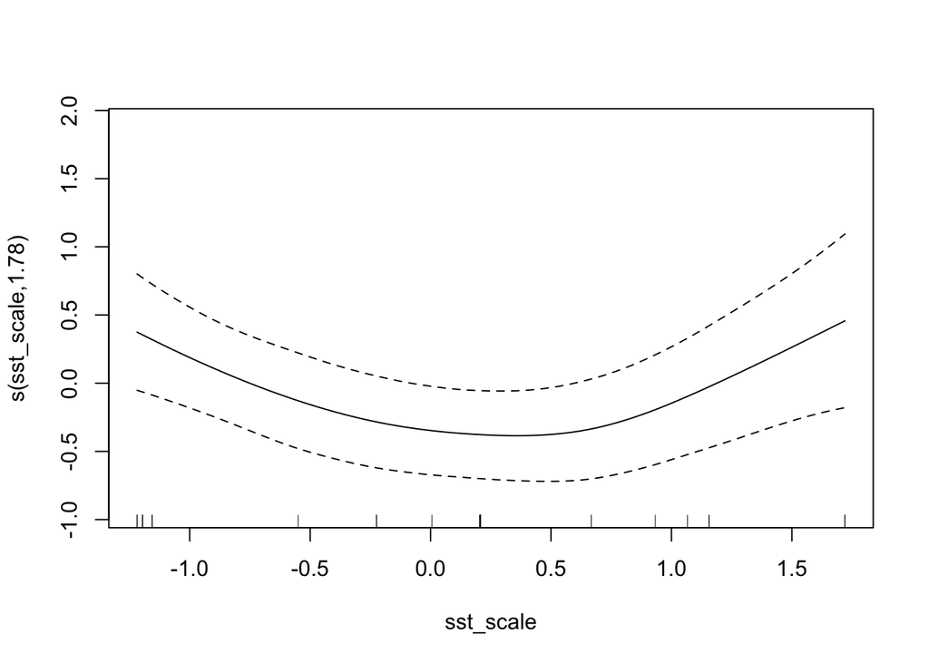

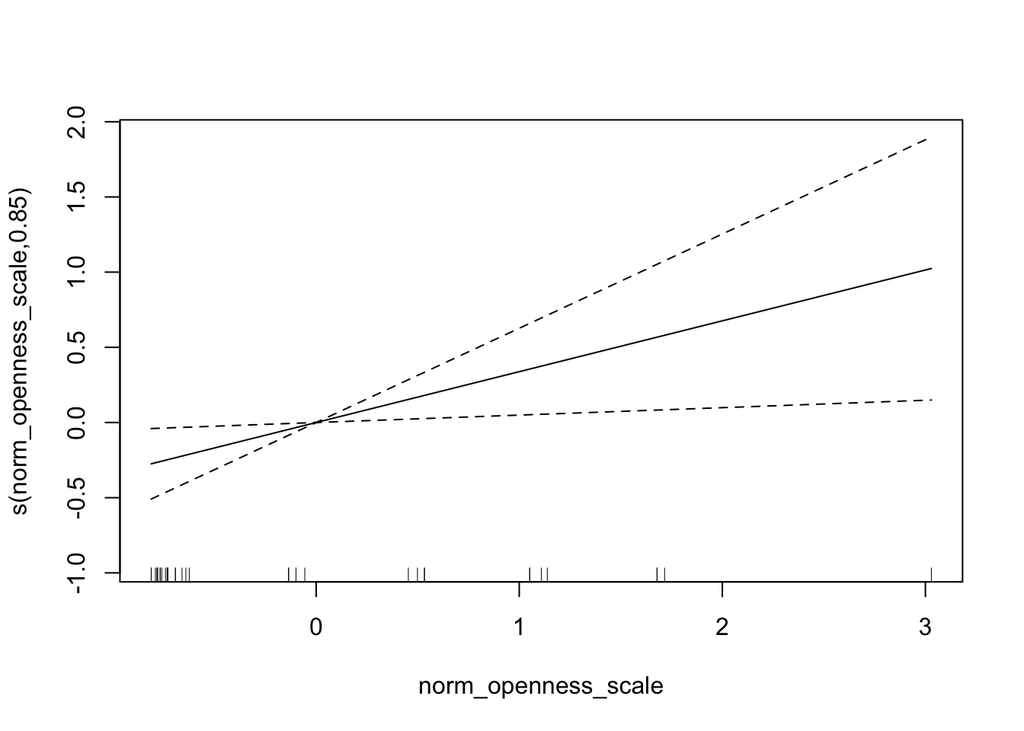

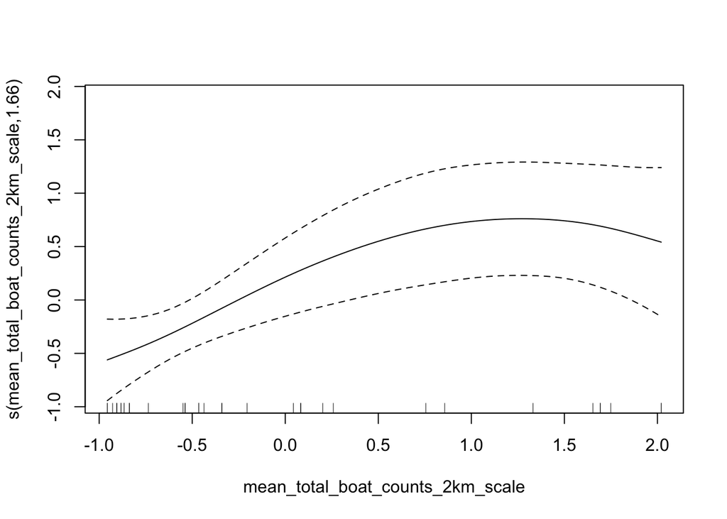

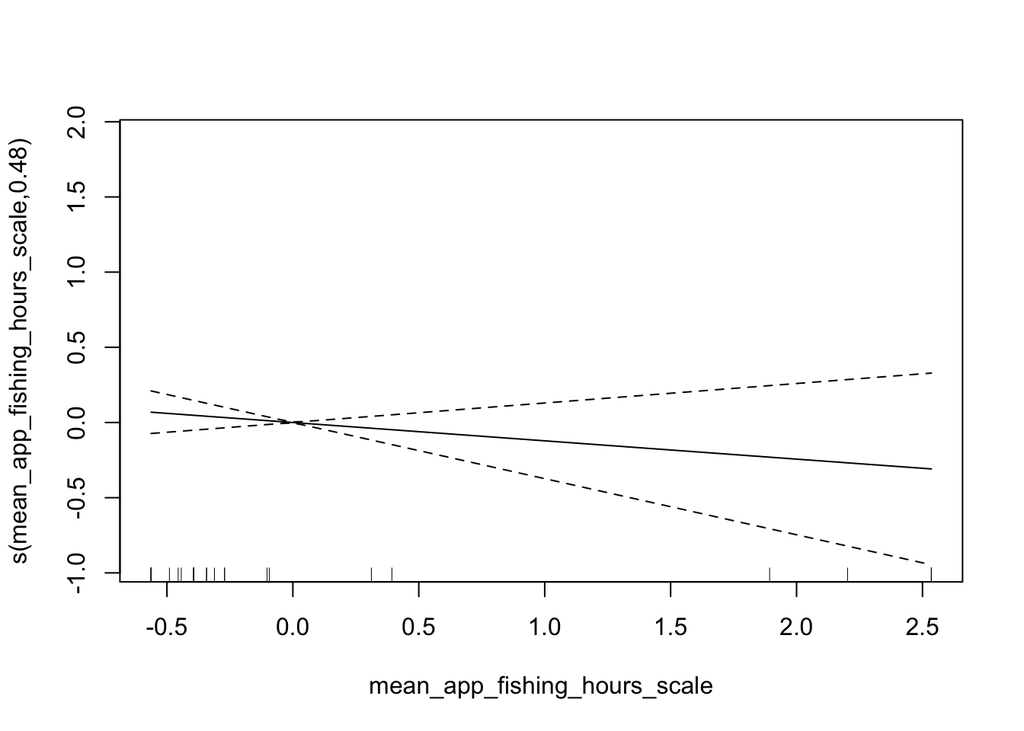

```
##
## Family: gaussian
## Link function: identity
##
## Formula:
## urch_sn_ratio ~ s(sst_scale) + s(norm_openness_scale) + s(mean_total_boat_counts_2km_scale) +
##     s(mean_app_fishing_hours_scale)
##
## Parametric coefficients:
##             Estimate Std. Error t value Pr(>|t|)
## (Intercept)   0.7446     0.1413    5.27 1.17e-05 ***
## ---
## Signif. codes:  0 '***' 0.001 '**' 0.01 '*' 0.05 '.' 0.1 ' ' 1
##
## Approximate significance of smooth terms:
##                                        edf Ref.df     F p-value
## s(sst_scale)                        1.7757      9 0.735 0.02606 *
## s(norm_openness_scale)              0.8458      9 0.609 0.01314 *
## s(mean_total_boat_counts_2km_scale) 1.6646      9 1.136 0.00326 **
## s(mean_app_fishing_hours_scale)     0.4842      9 0.104 0.16270
## ---
## Signif. codes:  0 '***' 0.001 '**' 0.01 '*' 0.05 '.' 0.1 ' ' 1
##
## R-sq.(adj) =  0.428   Deviance explained = 50.8%
## -REML = 49.028  Scale est. = 0.6987    n = 35
```

When using total boats that term seems to have more of an effect than rec boats fishing only.

##### Testing the residuals for autocorrelation

```
##
##  Moran I test under randomisation
##
## data:  residuals_total_mod_2km_total_boats
## weights: lw
## n reduced by no-neighbour observations
##
## Moran I statistic standard deviate = 2.1231, p-value = 0.01687
## alternative hypothesis: greater
## sample estimates:
## Moran I statistic       Expectation          Variance
##        0.58759399       -0.05882353        0.09270277
```

```
##
##  Moran I test under randomisation
##
## data:  residuals_total_mod_2km_total_boats
## weights: lw_inverse
##
## Moran I statistic standard deviate = 3.6383, p-value = 0.0001372
## alternative hypothesis: greater
## sample estimates:
## Moran I statistic       Expectation          Variance
##        0.57494225       -0.02941176        0.02759186
```

It appears that the residuals are autocorrelated. Will need to address this.

##### Testing the model for concurvity

```
## $worst
##                                             para s(sst_scale)
## para                                1.000000e+00 4.176841e-24
## s(sst_scale)                        4.182745e-24 1.000000e+00
## s(norm_openness_scale)              1.365135e-17 9.527043e-01
## s(mean_total_boat_counts_2km_scale) 7.111637e-20 9.796556e-01
## s(mean_app_fishing_hours_scale)     6.545409e-17 9.996134e-01
##                                     s(norm_openness_scale)
## para                                          1.365142e-17
## s(sst_scale)                                  9.527043e-01
## s(norm_openness_scale)                        1.000000e+00
## s(mean_total_boat_counts_2km_scale)           9.227043e-01
## s(mean_app_fishing_hours_scale)               8.987165e-01
##                                     s(mean_total_boat_counts_2km_scale)
## para                                                       7.111690e-20
## s(sst_scale)                                               9.796556e-01
## s(norm_openness_scale)                                     9.227043e-01
## s(mean_total_boat_counts_2km_scale)                        1.000000e+00
## s(mean_app_fishing_hours_scale)                            9.998520e-01
##                                     s(mean_app_fishing_hours_scale)
## para                                                   6.545414e-17
## s(sst_scale)                                           9.996134e-01
## s(norm_openness_scale)                                 8.987165e-01
## s(mean_total_boat_counts_2km_scale)                    9.998520e-01
## s(mean_app_fishing_hours_scale)                        1.000000e+00
##
## $observed
##                                             para s(sst_scale)
## para                                1.000000e+00 7.000881e-31
## s(sst_scale)                        4.182745e-24 1.000000e+00
## s(norm_openness_scale)              1.365135e-17 3.788238e-01
## s(mean_total_boat_counts_2km_scale) 7.111637e-20 7.333257e-01
## s(mean_app_fishing_hours_scale)     6.545409e-17 6.673966e-01
##                                     s(norm_openness_scale)
## para                                          1.013764e-33
## s(sst_scale)                                  4.675590e-01
## s(norm_openness_scale)                        1.000000e+00
## s(mean_total_boat_counts_2km_scale)           1.713128e-01
## s(mean_app_fishing_hours_scale)               1.606799e-01
##                                     s(mean_total_boat_counts_2km_scale)
```

[output cut: 22 more lines]

```
## s(norm_openness_scale)                        1.000000e+00
## s(mean_total_boat_counts_2km_scale)           1.852889e-01
## s(mean_app_fishing_hours_scale)               1.669555e-01
##                                     s(mean_total_boat_counts_2km_scale)
## para                                                       6.306762e-23
## s(sst_scale)                                               5.174706e-01
## s(norm_openness_scale)                                     3.058573e-01
## s(mean_total_boat_counts_2km_scale)                        1.000000e+00
## s(mean_app_fishing_hours_scale)                            6.297499e-01
##                                     s(mean_app_fishing_hours_scale)
## para                                                   5.634184e-21
## s(sst_scale)                                           4.095968e-01
## s(norm_openness_scale)                                 2.390114e-01
## s(mean_total_boat_counts_2km_scale)                    6.451047e-01
## s(mean_app_fishing_hours_scale)                        1.000000e+00
```

Some of the variables appear to have high concurvity scores in the worst case, but confidence intervals seem stable for the model plots. May need to get rid of the mean apparent fishing hours however. Since the concurvity was very high.

### Building GAMs on the urch sn ratio with TOTAL boats and averaged transects

#### Distribution of average urch sn ratio

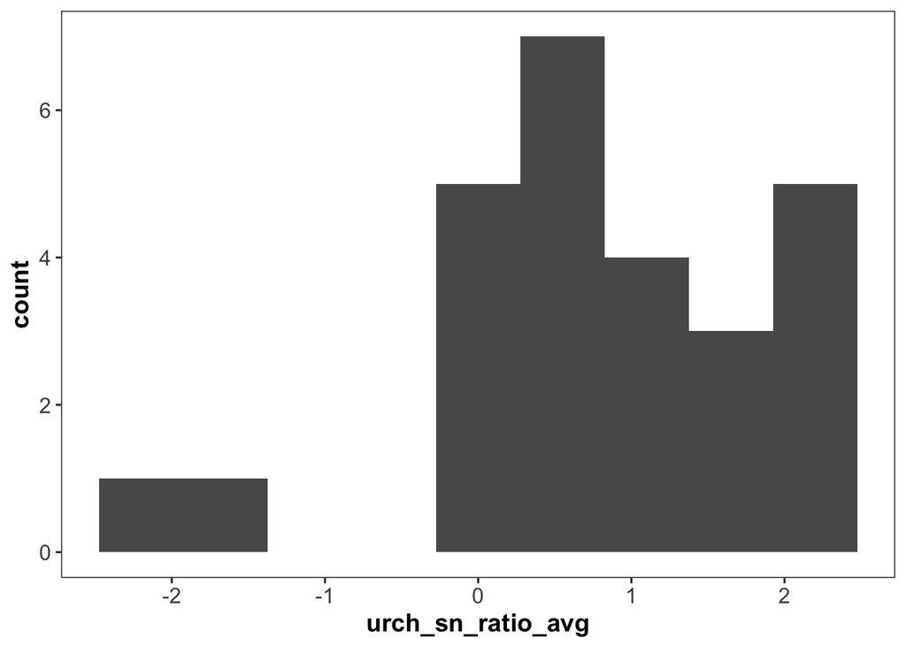

```r
ggplot(env_mod_data_avg, aes(x = urch_sn_ratio_avg))+
  geom_histogram(binwidth = 0.55)+
  theme.figure()
```

```r
#shapiro.test(env_mod_data_avg$urch_sn_ratio_avg)
#Says that average urch sn ratio is normal
```

#### Model with 1 km total boats avg

```r
total_mod_1km_total_boats_avg <- gam(urch_sn_ratio_avg ~ s(sst_scale) +
                   s(norm_openness_scale) +
                   s(mean_total_boat_counts_1km_scale)+
                   s(mean_app_fishing_hours_scale),
               data = env_mod_data_avg,
               family = gaussian(link = "identity"),
               method = 'REML',
               select = FALSE)
```

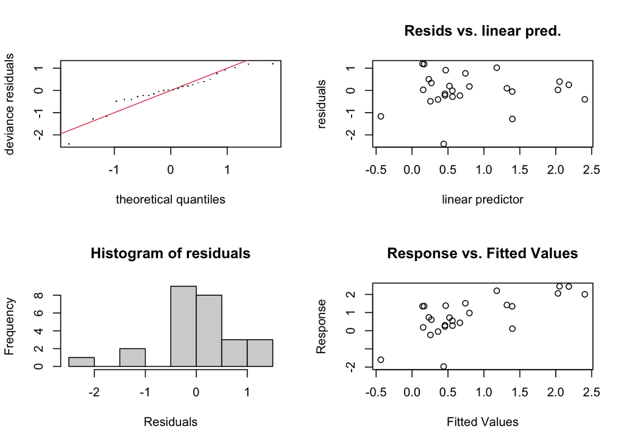

```
##
## Method: REML   Optimizer: outer newton
## full convergence after 12 iterations.
## Gradient range [-9.737761e-06,1.94938e-05]
## (score 35.0463 & scale 0.7614263).
## Hessian positive definite, eigenvalue range [8.875829e-07,10.50795].
## Model rank =  37 / 37
##
## Basis dimension (k) checking results. Low p-value (k-index<1) may
## indicate that k is too low, especially if edf is close to k'.
##
##                                       k'  edf k-index p-value
## s(sst_scale)                        9.00 1.58    1.05    0.51
## s(norm_openness_scale)              9.00 1.00    1.14    0.69
## s(mean_total_boat_counts_1km_scale) 9.00 1.00    1.09    0.68
## s(mean_app_fishing_hours_scale)     9.00 1.00    0.97    0.38
```

```
##                           (Intercept)                        s(sst_scale).1
##                          7.993946e-01                          4.381886e-02
##                        s(sst_scale).2                        s(sst_scale).3
##                         -1.095296e-01                         -2.393066e-02
##                        s(sst_scale).4                        s(sst_scale).5
##                         -8.546949e-02                          8.250499e-02
##                        s(sst_scale).6                        s(sst_scale).7
##                          7.803793e-02                          7.195187e-02
##                        s(sst_scale).8                        s(sst_scale).9
##                         -4.709917e-01                         -7.244246e-02
##              s(norm_openness_scale).1              s(norm_openness_scale).2
##                         -1.649398e-06                          3.556553e-06
##              s(norm_openness_scale).3              s(norm_openness_scale).4
##                          1.779746e-06                         -2.559217e-06
##              s(norm_openness_scale).5              s(norm_openness_scale).6
##                          1.229027e-06                         -2.966601e-06
##              s(norm_openness_scale).7              s(norm_openness_scale).8
##                          2.494532e-06                         -1.388866e-05
##              s(norm_openness_scale).9 s(mean_total_boat_counts_1km_scale).1
##                          4.056925e-01                         -4.129611e-06
## s(mean_total_boat_counts_1km_scale).2 s(mean_total_boat_counts_1km_scale).3
##                          7.453104e-06                         -4.144541e-06
## s(mean_total_boat_counts_1km_scale).4 s(mean_total_boat_counts_1km_scale).5
##                          5.550917e-06                          1.842163e-06
## s(mean_total_boat_counts_1km_scale).6 s(mean_total_boat_counts_1km_scale).7
##                         -5.164948e-06                         -5.164141e-06
## s(mean_total_boat_counts_1km_scale).8 s(mean_total_boat_counts_1km_scale).9
##                          2.303135e-05                          3.953157e-01
##     s(mean_app_fishing_hours_scale).1     s(mean_app_fishing_hours_scale).2
##                         -5.921162e-07                          4.823235e-07
##     s(mean_app_fishing_hours_scale).3     s(mean_app_fishing_hours_scale).4
##                         -4.835608e-07                         -5.130792e-07
##     s(mean_app_fishing_hours_scale).5     s(mean_app_fishing_hours_scale).6
##                          4.691334e-07                          4.933116e-07
##     s(mean_app_fishing_hours_scale).7     s(mean_app_fishing_hours_scale).8
##                          4.942079e-07                         -2.302334e-06
##     s(mean_app_fishing_hours_scale).9
##                         -2.688942e-01
```

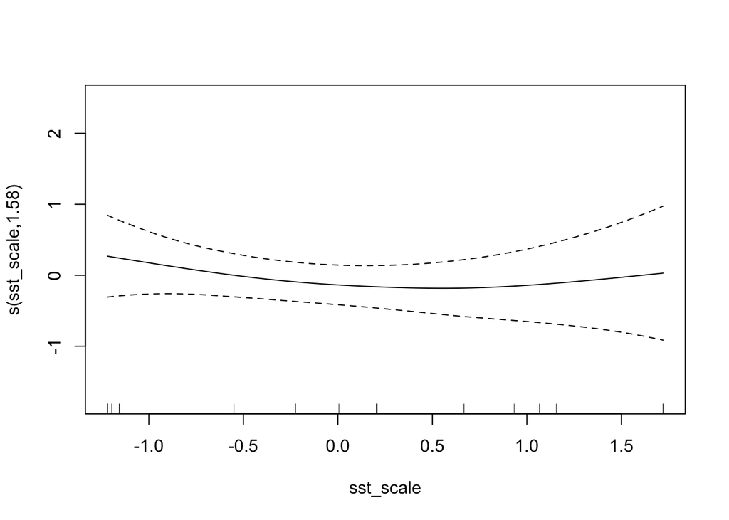

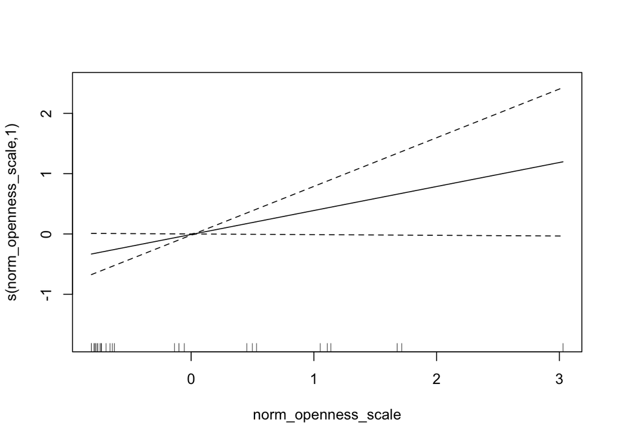

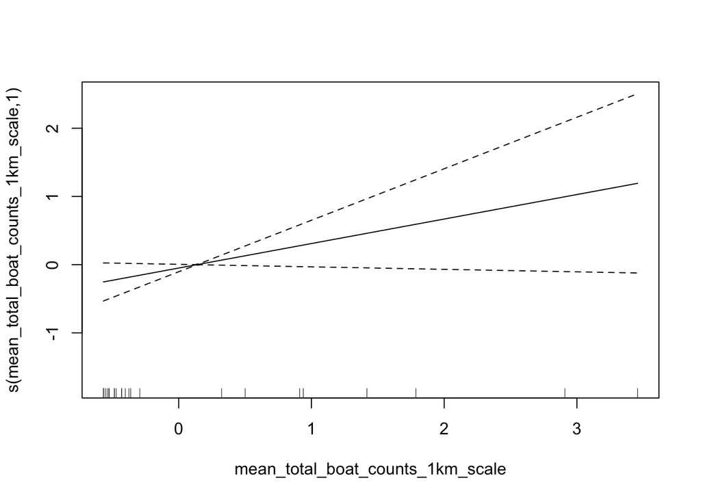

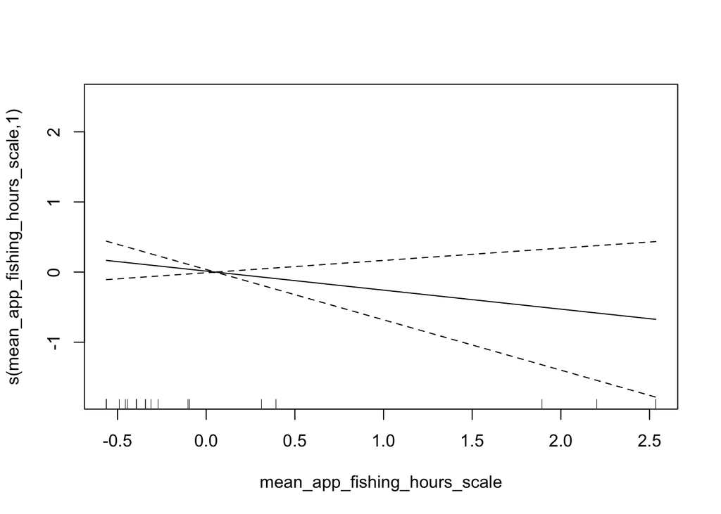

```
##
## Family: gaussian
## Link function: identity
##
## Formula:
## urch_sn_ratio_avg ~ s(sst_scale) + s(norm_openness_scale) + s(mean_total_boat_counts_1km_scale) +
##     s(mean_app_fishing_hours_scale)
##
## Parametric coefficients:
##             Estimate Std. Error t value Pr(>|t|)
## (Intercept)   0.7994     0.1711   4.671  0.00014 ***
## ---
## Signif. codes:  0 '***' 0.001 '**' 0.01 '*' 0.05 '.' 0.1 ' ' 1
##
## Approximate significance of smooth terms:
##                                       edf Ref.df     F p-value
## s(sst_scale)                        1.575   1.91 0.507  0.5376
## s(norm_openness_scale)              1.000   1.00 3.784  0.0659 .
## s(mean_total_boat_counts_1km_scale) 1.000   1.00 3.293  0.0846 .
## s(mean_app_fishing_hours_scale)     1.000   1.00 1.477  0.2384
## ---
## Signif. codes:  0 '***' 0.001 '**' 0.01 '*' 0.05 '.' 0.1 ' ' 1
##
## R-sq.(adj) =  0.358   Deviance explained = 47.6%
## -REML = 35.046  Scale est. = 0.76143   n = 26
```

##### Testing the residuals for autocorrelation

```
##
##  Moran I test under randomisation
##
## data:  residuals_total_mod_1km_total_boats_avg
## weights: lw_avg
## n reduced by no-neighbour observations
##
## Moran I statistic standard deviate = 0.55799, p-value = 0.2884
## alternative hypothesis: greater
## sample estimates:
## Moran I statistic       Expectation          Variance
##        0.07014652       -0.11111111        0.10552286
```

```
##
##  Moran I test under randomisation
##
## data:  residuals_total_mod_1km_total_boats_avg
## weights: lw_inverse_avg
##
## Moran I statistic standard deviate = 0.6945, p-value = 0.2437
## alternative hypothesis: greater
## sample estimates:
## Moran I statistic       Expectation          Variance
##       0.010742869      -0.040000000       0.005338357
```

No spatial autocorrelation.

##### Testing the model for concurvity

```
## $worst
##                                             para s(sst_scale)
## para                                1.000000e+00 2.111799e-24
## s(sst_scale)                        2.106192e-24 1.000000e+00
## s(norm_openness_scale)              2.630097e-23 9.517659e-01
## s(mean_total_boat_counts_1km_scale) 5.824135e-18 8.292860e-01
## s(mean_app_fishing_hours_scale)     1.429345e-18 9.996369e-01
##                                     s(norm_openness_scale)
## para                                          2.633319e-23
## s(sst_scale)                                  9.517659e-01
## s(norm_openness_scale)                        1.000000e+00
## s(mean_total_boat_counts_1km_scale)           9.744619e-01
## s(mean_app_fishing_hours_scale)               9.129862e-01
##                                     s(mean_total_boat_counts_1km_scale)
## para                                                       5.824126e-18
## s(sst_scale)                                               8.292860e-01
## s(norm_openness_scale)                                     9.744619e-01
## s(mean_total_boat_counts_1km_scale)                        1.000000e+00
## s(mean_app_fishing_hours_scale)                            9.999939e-01
##                                     s(mean_app_fishing_hours_scale)
## para                                                   1.429339e-18
## s(sst_scale)                                           9.996369e-01
## s(norm_openness_scale)                                 9.129862e-01
## s(mean_total_boat_counts_1km_scale)                    9.999939e-01
## s(mean_app_fishing_hours_scale)                        1.000000e+00
##
## $observed
##                                             para s(sst_scale)
## para                                1.000000e+00 3.892497e-31
## s(sst_scale)                        2.106192e-24 1.000000e+00
## s(norm_openness_scale)              2.630097e-23 5.421440e-01
## s(mean_total_boat_counts_1km_scale) 5.824135e-18 4.050239e-01
## s(mean_app_fishing_hours_scale)     1.429345e-18 4.719556e-01
##                                     s(norm_openness_scale)
## para                                          1.895839e-33
## s(sst_scale)                                  4.948969e-01
## s(norm_openness_scale)                        1.000000e+00
## s(mean_total_boat_counts_1km_scale)           2.869142e-01
## s(mean_app_fishing_hours_scale)               2.048892e-01
##                                     s(mean_total_boat_counts_1km_scale)
```

[output cut: 22 more lines]

```
## s(norm_openness_scale)                        1.000000e+00
## s(mean_total_boat_counts_1km_scale)           2.322177e-01
## s(mean_app_fishing_hours_scale)               2.003710e-01
##                                     s(mean_total_boat_counts_1km_scale)
## para                                                       1.033135e-21
## s(sst_scale)                                               4.535350e-01
## s(norm_openness_scale)                                     7.275295e-01
## s(mean_total_boat_counts_1km_scale)                        1.000000e+00
## s(mean_app_fishing_hours_scale)                            6.453285e-01
##                                     s(mean_app_fishing_hours_scale)
## para                                                   1.313946e-22
## s(sst_scale)                                           3.517142e-01
## s(norm_openness_scale)                                 3.150262e-01
## s(mean_total_boat_counts_1km_scale)                    7.341869e-01
## s(mean_app_fishing_hours_scale)                        1.000000e+00
```

Some of the variables appear to have high concurvity scores in the worst case, but confidence intervals seem stable for the model plots. May need to get rid of the mean apparent fishing hours however. Since the concurvity was very high.

#### Model with 1.5 km total boats avg

```r
total_mod_1.5km_total_boats_avg <- gam(urch_sn_ratio_avg ~ s(sst_scale) +
                   s(norm_openness_scale) +
                   s(mean_total_boat_counts_1.5km_scale)+
                   s(mean_app_fishing_hours_scale),
               data = env_mod_data_avg,
               family = gaussian(link = "identity"),
               method = 'REML',
               select = TRUE)
```

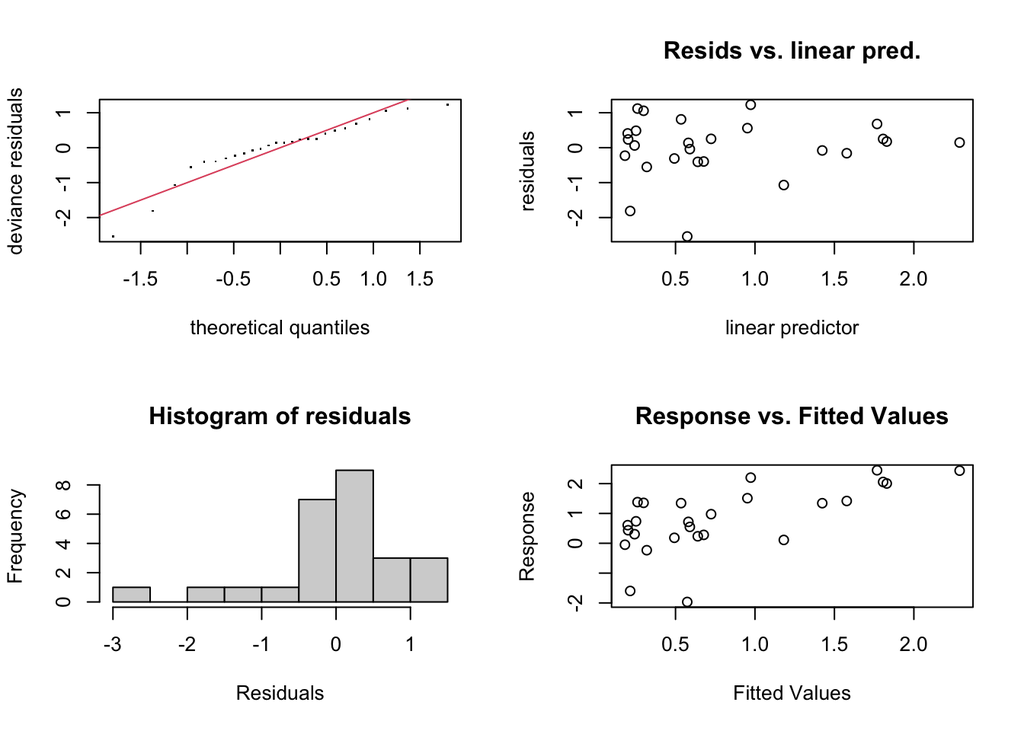

```
##
## Method: REML   Optimizer: outer newton
## full convergence after 16 iterations.
## Gradient range [-7.545058e-06,4.16421e-06]
## (score 35.38839 & scale 0.754257).
## Hessian positive definite, eigenvalue range [1.298267e-06,12.52665].
## Model rank =  37 / 37
##
## Basis dimension (k) checking results. Low p-value (k-index<1) may
## indicate that k is too low, especially if edf is close to k'.
##
##                                             k'      edf k-index p-value
## s(sst_scale)                          9.00e+00 4.87e-04    1.05    0.55
## s(norm_openness_scale)                9.00e+00 9.17e-01    1.08    0.60
## s(mean_total_boat_counts_1.5km_scale) 9.00e+00 6.76e-01    1.03    0.58
## s(mean_app_fishing_hours_scale)       9.00e+00 1.25e-05    1.05    0.49
```

```
##                             (Intercept)                          s(sst_scale).1
##                            7.993946e-01                            2.570661e-05
##                          s(sst_scale).2                          s(sst_scale).3
##                           -2.616035e-05                           -1.045292e-05
##                          s(sst_scale).4                          s(sst_scale).5
##                           -2.769610e-05                            2.680281e-05
##                          s(sst_scale).6                          s(sst_scale).7
##                            2.361432e-05                            1.968385e-05
##                          s(sst_scale).8                          s(sst_scale).9
##                           -1.567510e-04                           -3.536531e-07
##                s(norm_openness_scale).1                s(norm_openness_scale).2
##                           -2.501665e-06                            9.946075e-07
##                s(norm_openness_scale).3                s(norm_openness_scale).4
##                            3.529264e-07                           -3.984817e-07
##                s(norm_openness_scale).5                s(norm_openness_scale).6
##                            1.411819e-08                           -6.360907e-08
##                s(norm_openness_scale).7                s(norm_openness_scale).8
##                            9.554127e-08                            1.556484e-06
##                s(norm_openness_scale).9 s(mean_total_boat_counts_1.5km_scale).1
##                            5.439872e-01                           -1.088427e-06
## s(mean_total_boat_counts_1.5km_scale).2 s(mean_total_boat_counts_1.5km_scale).3
##                           -1.551732e-06                            3.049854e-07
## s(mean_total_boat_counts_1.5km_scale).4 s(mean_total_boat_counts_1.5km_scale).5
##                            1.486148e-06                            8.315340e-08
## s(mean_total_boat_counts_1.5km_scale).6 s(mean_total_boat_counts_1.5km_scale).7
##                           -1.403487e-06                           -1.061987e-06
## s(mean_total_boat_counts_1.5km_scale).8 s(mean_total_boat_counts_1.5km_scale).9
##                            6.527517e-06                            2.040065e-01
##       s(mean_app_fishing_hours_scale).1       s(mean_app_fishing_hours_scale).2
##                           -8.792734e-07                            1.312688e-07
##       s(mean_app_fishing_hours_scale).3       s(mean_app_fishing_hours_scale).4
##                           -3.984159e-07                           -2.529876e-07
##       s(mean_app_fishing_hours_scale).5       s(mean_app_fishing_hours_scale).6
##                            2.885983e-07                            3.324048e-07
##       s(mean_app_fishing_hours_scale).7       s(mean_app_fishing_hours_scale).8
##                            3.225189e-07                           -1.718080e-06
##       s(mean_app_fishing_hours_scale).9
##                           -5.967389e-07
```

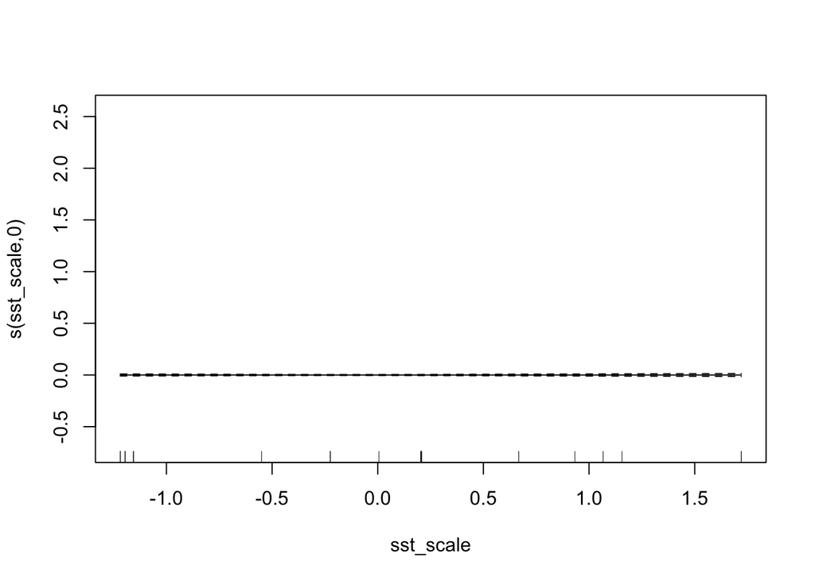